# PWA GAP ANALYSIS - Technical Report

- **Created by Kevin Muhia Gathogo**
- **Created on Jul 29, 2021**
- **Runned on Mar 25, 2022** (`feature.shape, Gives Current (x, y) x -total rows/features and y the current fields`)

This is a gap analysis for the following Dataset in SDE 64.

## DRAINAGE

### C. TREATED EFFLUENT NETWORK

This is an insight on the Feature classes attribute Completeness. The report highlight the Gaps existing in the dataset in the context of attributes having Null fields. it gives numerical quantity of each attribute field total null/un-filled fields as well as a graphical represention with other columns of a feature class.

Below are the feature classes existing in SDE.DRG_TREATED_EFFLUENT_NETWORK, whose gaps have been assessed.

```
•   TSE Area Engineer Boundary
•   TSE Lagoon & Tanks
•   TSE Scada Zone Boundary
•   Treated Sewage Network Takamul Supply Zone Catchment Boundries
•   TSE Valve Chamber
•   TSE Duct
•   Treated Effluent Pipe
•   TSE Stub Pipe
•   TSE Cover
•   TSE Distribution Chamber Corner
•   TSE Distribution Chamber
•   Fire Hydrant
•   TSE Fittings
•   TSE Flow Meter Chamber
•   TSE Deep Injection Well
•   TSE Pumping Station
•   TSE Sample Points
•   TSE Stub End (End Cap)
•   TSE Sump
•   TSE Valve
•   TSE Valve Chamber
•   TSE Water Tower
```

```python
import pandas as pd
from arcgis import GIS
import matplotlib.pyplot as plt
%matplotlib inline
```

### 1. TSE Area Engineer Boundary

TSE Area Engineer Boundary feature class has:

```
    •   Attribute Fields (Columns): 29
    •   Total Records (Rows): 4
```

Below is a representation of null values for each attribute field

```python
TSE_Area_Engineer_Boundary = pd.DataFrame.spatial.from_featureclass(r"C:\Users\esd_kgathogo\AppData\Roaming\ESRI\Desktop10.7\ArcCatalog\PWAROADS.sde\SDE.DRG_TREATED_EFFLUENT_NETWORK\SDE.TEARENGB")
TSE_Area_Engineer_Boundary.head(2)
```

|  | OBJECTID | ID | GROUP_ | GLOBALID | SUBTYPE_CODE | GFCODE | STATUS | ASSET_TAG | MXASSETNUM | MXLOCATION | MXSITEID | MXCREATIONSTATE | ROWSTAMP | MXSTATUS | PARENT_GLOBALID | LOCATION_GLOBAL_ID | DATA_LOAD_ID | DISCIPLINE | GPS_X | GPS_Y | GPS_Z | OPERATOR | MAINTAINER | MUNICIPALITY | DISTRICT | CONTRACT_ID | PROJECT_ID | ASSET_PRIORITY | SHAPE |
| --- | --- | --- | --- | --- | --- | --- | --- | --- | --- | --- | --- | --- | --- | --- | --- | --- | --- | --- | --- | --- | --- | --- | --- | --- | --- | --- | --- | --- | --- |
| 0 | 7385 | 0 | Group 2 | {47510FC1-4C41-41C6-AFA8-A9103D405C21} | 1 | TEARENGB | Operational | None | None | None | None | None | 0 | None | None | None | None | None | 51.388117 | 25.277585 | None | None | None | None | None | None | None | None | {"rings": [[[218981.02109999955, 395081.030899... |
| 1 | 7386 | 0 | Group 4 | {4C3288D0-CEBD-4815-A2AB-A6785FD335B6} | 1 | TEARENGB | Operational | None | None | None | None | None | 0 | None | None | None | None | None | 51.345737 | 25.150535 | None | None | None | None | None | None | None | None | {"rings": [[[229584.37770000007, 385917.786100... |

```python
TSE_Area_Engineer_Boundary.shape
```

```
(4, 29)
```

```python
TSE_Area_Engineer_Boundary_null = pd.DataFrame(TSE_Area_Engineer_Boundary.isnull().sum())
```

```python
TSE_Area_Engineer_Boundary_null
```

|  | 0 |
| --- | --- |
| OBJECTID | 0 |
| ID | 0 |
| GROUP_ | 0 |
| GLOBALID | 0 |
| SUBTYPE_CODE | 0 |
| GFCODE | 0 |
| STATUS | 0 |
| ASSET_TAG | 4 |
| MXASSETNUM | 4 |
| MXLOCATION | 4 |
| MXSITEID | 4 |
| MXCREATIONSTATE | 4 |
| ROWSTAMP | 0 |
| MXSTATUS | 4 |
| PARENT_GLOBALID | 4 |
| LOCATION_GLOBAL_ID | 4 |
| DATA_LOAD_ID | 4 |
| DISCIPLINE | 4 |
| GPS_X | 0 |
| GPS_Y | 0 |
| GPS_Z | 4 |
| OPERATOR | 4 |
| MAINTAINER | 4 |
| MUNICIPALITY | 4 |
| DISTRICT | 4 |
| CONTRACT_ID | 4 |
| PROJECT_ID | 4 |
| ASSET_PRIORITY | 4 |
| SHAPE | 0 |

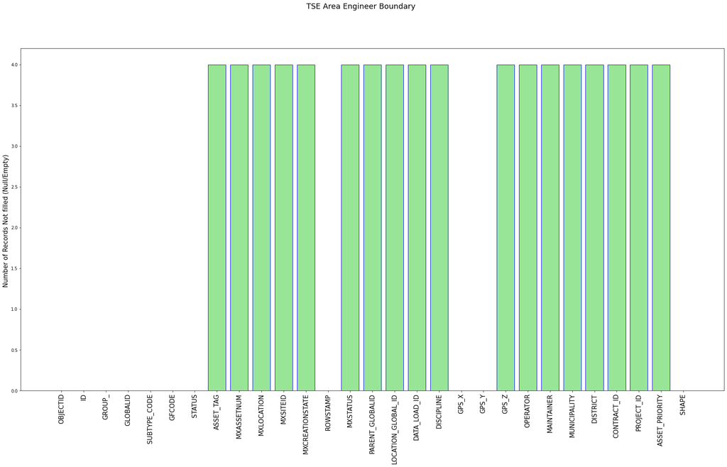

```python
x = TSE_Area_Engineer_Boundary.columns
y = TSE_Area_Engineer_Boundary.isnull().sum()
plt.figure(figsize=(30,15))
plt.bar(x, y, color= (0.2,0.8,0.2,0.5),  edgecolor='Blue')
plt.suptitle("TSE Area Engineer Boundary", fontsize=18)
plt.ylabel("Number of Records Not filled (Null/Empty) ", fontsize=15)
plt.xticks(rotation=90, fontsize=15)
plt.show()
```

### 2. TSE Lagoon & Tanks

TSE Lagoon & Tanks feature class has:

```
    •   Attribute Fields (Columns): 220
    •   Total Records (Rows): 26
```

Below is a representation of null values for each attribute field

```python
TSE_Lagoon_Tanks = pd.DataFrame.spatial.from_featureclass(r"C:\Users\esd_kgathogo\AppData\Roaming\ESRI\Desktop10.7\ArcCatalog\PWAROADS.sde\SDE.DRG_TREATED_EFFLUENT_NETWORK\SDE.TEARLGON")
TSE_Lagoon_Tanks.head(2)
```

|  | OBJECTID | GFCODE | PROJECT_CODE | PROJECT_STATUS | RD_ANAME | RD_ENAME | STREET_NO | ZONE_NO | FEATURE_REMARKS | SOURCE_DATA_INPUT_FORMAT | DATA_INPUT_METHOD | METADATA | SOURCE_DEPT_SECTION_UNIT | OWNER | DATE_CREATED | EDITED_BY | LAST_UPDATED_DATE | BUSINESS_APPROVAL_BY | BUSINESS_APPROVAL_DATE | CONDITIONAL_DATA_APPROVAL_BY | CONDITIONAL_DATA_APPROVAL_DATE | DATA_QC_APPROVAL_BY | DATA_QC_APPROVAL_DATE | COST_PER_ITEM_METER | STOCK_ON_HAND | AGENCY_NAME | DMS_CODE | TANK_NUM | TANK_TYPE | … |
| --- | --- | --- | --- | --- | --- | --- | --- | --- | --- | --- | --- | --- | --- | --- | --- | --- | --- | --- | --- | --- | --- | --- | --- | --- | --- | --- | --- | --- | --- | --- |
| 0 | 12519 | TEARLGON | DOM/1546/4.07 | None | None | None | NaN | NaN | None | None | None | None | Drainage O&M | O&M Drainage | NaT | Ayman | 2017-12-10 09:46:26 | None | None | None | NaT | None | NaT | None | None | None | None | I/LAGOON_2 | LAGOON | … |
| 1 | 12520 | TEARLGON | AADOM13-14M1523-4.07 I | As Built | None | INDUSTRIALAREADOHA | NaN | NaN | None | Excel | Manual | None | Drainage O&M | O&M Drainage | 2015-03-31 | EJRC/Ayman | 2017-12-10 09:46:26 | None | None | ELANGO | 2015-03-24 07:58:30 | None | NaT | None | None | Ashghal | None | I/LAGOON_1 | 2 | … |

2 rows × 220 columns

```python
TSE_Lagoon_Tanks.shape
```

```
(26, 220)
```

```python
TSE_Lagoon_Tanks_null = pd.DataFrame(TSE_Lagoon_Tanks.isnull().sum())
TSE_Lagoon_Tanks_null
```

|  | 0 |
| --- | --- |
| OBJECTID | 0 |
| GFCODE | 0 |
| PROJECT_CODE | 2 |
| PROJECT_STATUS | 2 |
| RD_ANAME | 26 |
| ... | ... |
| DISTRICT | 26 |
| CONTRACT_ID | 25 |
| PROJECT_ID | 26 |
| ASSET_PRIORITY | 26 |
| SHAPE | 0 |

220 rows × 1 columns

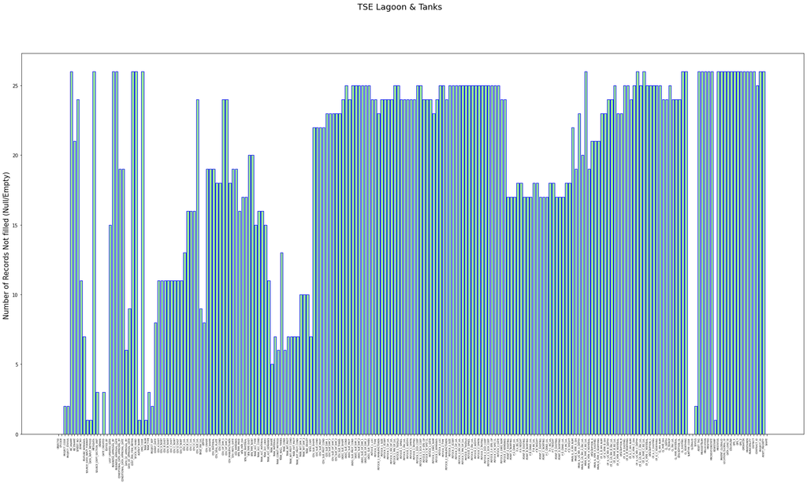

```python
x = TSE_Lagoon_Tanks.columns
y = TSE_Lagoon_Tanks.isnull().sum()
plt.figure(figsize=(30,15))
plt.bar(x, y, color= (0.2,0.8,0.2,0.5),  edgecolor='Blue')
plt.suptitle("TSE Lagoon & Tanks", fontsize=18)
plt.ylabel("Number of Records Not filled (Null/Empty) ", fontsize=15)
plt.xticks(rotation=90, fontsize=5)
plt.show()
```

### 3. TSE Scada Zone Boundary

TSE Scada Zone Boundary feature class has:

```
    •   Attribute Fields (Columns): 29
    •   Total Records (Rows): 12
```

```python
TSE_Scada_Zone_Boundary = pd.DataFrame.spatial.from_featureclass(r"C:\Users\esd_kgathogo\AppData\Roaming\ESRI\Desktop10.7\ArcCatalog\PWAROADS.sde\SDE.DRG_TREATED_EFFLUENT_NETWORK\SDE.TEARSCZN")
TSE_Scada_Zone_Boundary.head(2)
```

|  | OBJECTID | ID | SCADAZO | GLOBALID | SUBTYPE_CODE | GFCODE | STATIS | ASSET_TAG | MXASSETNUM | MXLOCATION | MXSITEID | MXCREATIONSTATE | ROWSTAMP | MXSTATUS | PARENT_GLOBALID | LOCATION_GLOBAL_ID | DATA_LOAD_ID | DISCIPLINE | GPS_X | GPS_Y | GPS_Z | OPERATOR | MAINTAINER | MUNICIPALITY | DISTRICT | CONTRACT_ID | PROJECT_ID | ASSET_PRIORITY | SHAPE |
| --- | --- | --- | --- | --- | --- | --- | --- | --- | --- | --- | --- | --- | --- | --- | --- | --- | --- | --- | --- | --- | --- | --- | --- | --- | --- | --- | --- | --- | --- |
| 0 | 11881 | 0 | Zone 12 | {C7EE3821-D8C2-4115-AFA4-AAE9A859389E} | 1 | TEARSCZN | Operational | None | None | None | None | None | 0 | None | None | None | None | None | 51.226134 | 25.109633 | None | None | None | None | None | None | None | None | {"rings": [[[217797.74409999978, 381045.446699... |
| 1 | 11882 | 0 | Zone 10 | {AFB424E6-FA56-4B46-91B4-5785594492A0} | 1 | TEARSCZN | Operational | None | None | None | None | None | 0 | None | None | None | None | None | 51.435360 | 25.185246 | None | None | None | None | None | None | None | None | {"rings": [[[221972.63989999983, 385562.928200... |

```python
TSE_Scada_Zone_Boundary.shape
```

```
(12, 29)
```

```python
TSE_Scada_Zone_Boundary_null = pd.DataFrame(TSE_Scada_Zone_Boundary.isnull().sum())
TSE_Scada_Zone_Boundary_null
```

|  | 0 |
| --- | --- |
| OBJECTID | 0 |
| ID | 0 |
| SCADAZO | 0 |
| GLOBALID | 0 |
| SUBTYPE_CODE | 0 |
| GFCODE | 0 |
| STATIS | 0 |
| ASSET_TAG | 12 |
| MXASSETNUM | 12 |
| MXLOCATION | 12 |
| MXSITEID | 12 |
| MXCREATIONSTATE | 12 |
| ROWSTAMP | 0 |
| MXSTATUS | 12 |
| PARENT_GLOBALID | 12 |
| LOCATION_GLOBAL_ID | 12 |
| DATA_LOAD_ID | 12 |
| DISCIPLINE | 12 |
| GPS_X | 0 |
| GPS_Y | 0 |
| GPS_Z | 12 |
| OPERATOR | 12 |
| MAINTAINER | 12 |
| MUNICIPALITY | 12 |
| DISTRICT | 12 |
| CONTRACT_ID | 12 |
| PROJECT_ID | 12 |
| ASSET_PRIORITY | 12 |
| SHAPE | 0 |

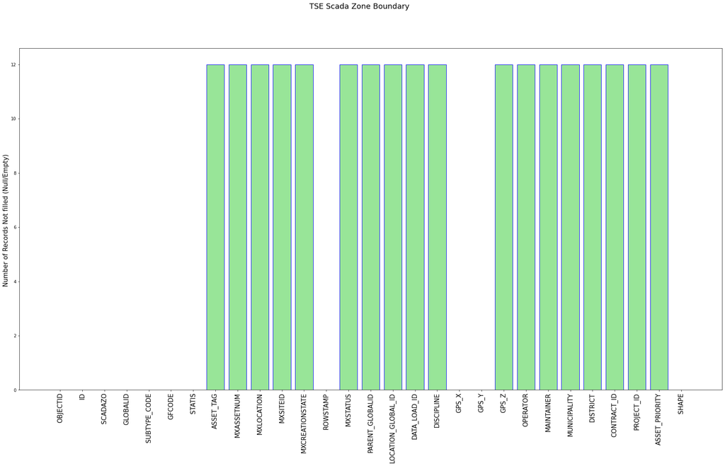

```python
x = TSE_Scada_Zone_Boundary.columns
y = TSE_Scada_Zone_Boundary.isnull().sum()
plt.figure(figsize=(30,15))
plt.bar(x, y, color= (0.2,0.8,0.2,0.5),  edgecolor='Blue')
plt.suptitle("TSE Scada Zone Boundary", fontsize=18)
plt.ylabel("Number of Records Not filled (Null/Empty) ", fontsize=15)
plt.xticks(rotation=90, fontsize=15)
plt.show()
```

### 4. Treated Sewage Network Takamul Supply Zone Catchment Boundries

Treated Sewage Network Takamul Supply Zone Catchment Boundries feature class has:

```
    •   Attribute Fields (Columns): 7
    •   Total Records (Rows): 4
```

```python
TSE_Takamul_Supply_Zn_Catchment_Bd = pd.DataFrame.spatial.from_featureclass(r"C:\Users\esd_kgathogo\AppData\Roaming\ESRI\Desktop10.7\ArcCatalog\PWAROADS.sde\SDE.DRG_TREATED_EFFLUENT_NETWORK\SDE.TEARSZCB")
TSE_Takamul_Supply_Zn_Catchment_Bd.head(2)
```

|  | OBJECTID | ID | CATCHMENT | CONTRACTOR_ID | CONTRACTOR | GLOBALID | SHAPE |
| --- | --- | --- | --- | --- | --- | --- | --- |
| 0 | 642 | None | Qatar South | C/2020/28 | METITO (OVERSEAS) QATAR | {9D5A5224-D70C-49D2-AABA-CAD33A0AB884} | {"rings": [[[239584.1129999999, 394354.3019999... |
| 1 | 643 | None | Qatar West | C/2020/50 | AGUAS DE VALENCIA - MACE QATAR JV | {381A1E39-7E86-40E2-9EE7-838F192F5F03} | {"rings": [[[211780.48869999964, 380073.057499... |

```python
TSE_Takamul_Supply_Zn_Catchment_Bd.shape
```

```
(4, 7)
```

```python
TSE_Takamul_Supply_Zn_Catchment_Bd_null = pd.DataFrame(TSE_Takamul_Supply_Zn_Catchment_Bd.isnull().sum())
TSE_Takamul_Supply_Zn_Catchment_Bd_null
```

|  | 0 |
| --- | --- |
| OBJECTID | 0 |
| ID | 4 |
| CATCHMENT | 0 |
| CONTRACTOR_ID | 1 |
| CONTRACTOR | 1 |
| GLOBALID | 0 |
| SHAPE | 0 |

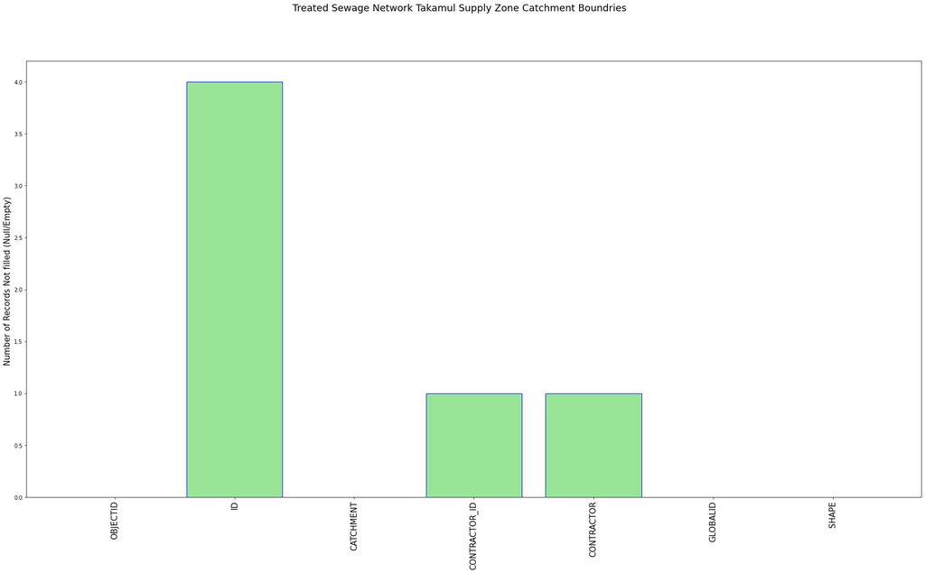

```python
x = TSE_Takamul_Supply_Zn_Catchment_Bd.columns
y = TSE_Takamul_Supply_Zn_Catchment_Bd.isnull().sum()
plt.figure(figsize=(30,15))
plt.bar(x, y, color= (0.2,0.8,0.2,0.5),  edgecolor='Blue')
plt.suptitle("Treated Sewage Network Takamul Supply Zone Catchment Boundries", fontsize=18)
plt.ylabel("Number of Records Not filled (Null/Empty) ", fontsize=15)
plt.xticks(rotation=90, fontsize=15)
plt.show()
```

### 5. TSE Valve Chamber

TSE Valve Chamber feature class has:

[output not shown]

```python
TSE_Valve_Chamber = pd.DataFrame.spatial.from_featureclass(r"C:\Users\esd_kgathogo\AppData\Roaming\ESRI\Desktop10.7\ArcCatalog\PWAROADS.sde\SDE.DRG_TREATED_EFFLUENT_NETWORK\SDE.TEARVLCH")
TSE_Valve_Chamber.head(2)
```

|  | OBJECTID | GFCODE | PROJECT_CODE | PROJECT_STATUS | RD_ANAME | RD_ENAME | STREET_NO | ZONE_NO | FEATURE_REMARKS | SOURCE_DATA_INPUT_FORMAT | DATA_INPUT_METHOD | METADATA | SOURCE_DEPT_SECTION_UNIT | OWNER | DATE_CREATED | EDITED_BY | LAST_UPDATED_DATE | BUSINESS_APPROVAL_BY | BUSINESS_APPROVAL_DATE | CONDITIONAL_DATA_APPROVAL_BY | CONDITIONAL_DATA_APPROVAL_DATE | DATA_QC_APPROVAL_BY | DATA_QC_APPROVAL_DATE | COST_PER_ITEM_METER | STOCK_ON_HAND | AGENCY_NAME | DMS_CODE | ARVLCH_KY | PROJECT_REF | … |
| --- | --- | --- | --- | --- | --- | --- | --- | --- | --- | --- | --- | --- | --- | --- | --- | --- | --- | --- | --- | --- | --- | --- | --- | --- | --- | --- | --- | --- | --- | --- |
| 0 | 224486 | TEARVLCH | IA 12/13 C 055 ST | As Built | طريق الوكرة | Al Wakra Road | 311.0 | 90.0 | None | Excel | Automation | None | Drainage O&M | O&M Drainage | 2019-03-12 11:00:44 | ES/VV | 2020-09-10 | None | None | None | NaT | ES/BD | 2020-09-27 | None | None | Ashghal | None | NaN | C2013/57 | … |
| 1 | 224318 | TEARVLCH | IA 12/13 C 055 ST | As Built | الطريق الدائري السابع | G Ring Road | 2000.0 | 91.0 | None | Excel | Automation | None | Drainage O&M | O&M Drainage | 2019-03-12 11:00:44 | ES/VV | 2020-09-10 | None | None | None | NaT | ES/BD | 2020-09-27 | None | None | Ashghal | None | NaN | C2013/57 | … |

2 rows × 106 columns

```python
TSE_Valve_Chamber.shape
```

```
(7285, 106)
```

```python
TSE_Valve_Chamber_null = pd.DataFrame(TSE_Valve_Chamber.isnull().sum())
TSE_Valve_Chamber_null
```

|  | 0 |
| --- | --- |
| OBJECTID | 0 |
| GFCODE | 0 |
| PROJECT_CODE | 529 |
| PROJECT_STATUS | 1271 |
| RD_ANAME | 6457 |
| ... | ... |
| DISTRICT | 7285 |
| CONTRACT_ID | 7282 |
| PROJECT_ID | 7285 |
| ASSET_PRIORITY | 7165 |
| SHAPE | 0 |

106 rows × 1 columns

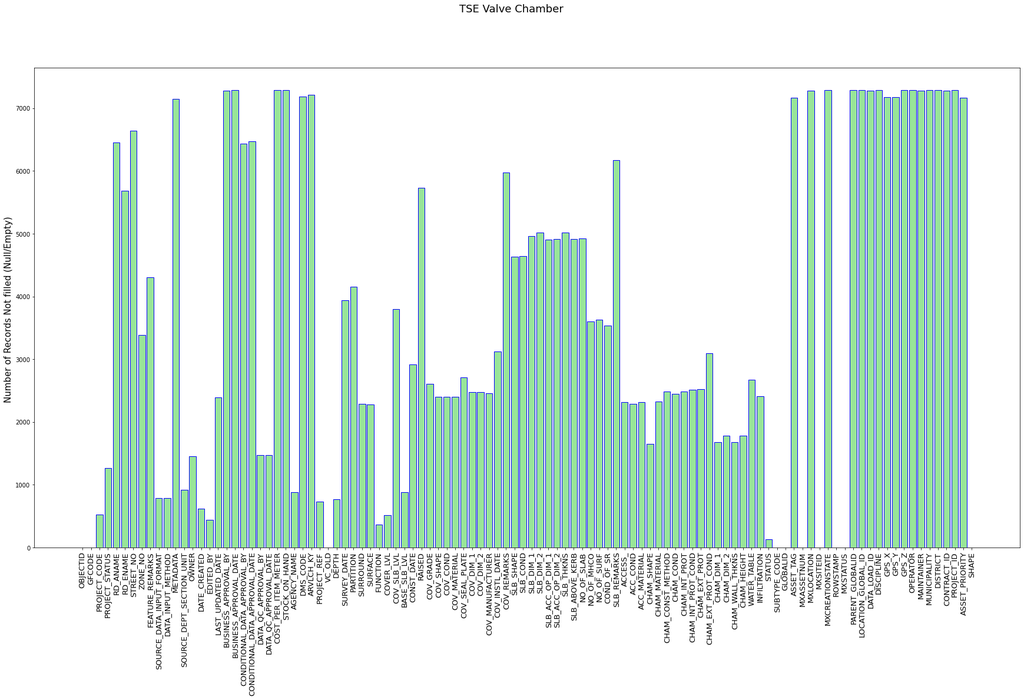

```python
x = TSE_Valve_Chamber.columns
y = TSE_Valve_Chamber.isnull().sum()
plt.figure(figsize=(30,15))
plt.bar(x, y, color= (0.2,0.8,0.2,0.5),  edgecolor='Blue')
plt.suptitle("TSE Valve Chamber", fontsize=18)
plt.ylabel("Number of Records Not filled (Null/Empty) ", fontsize=15)
plt.xticks(rotation=90, fontsize=13)
plt.show()
```

### 6. TSE Duct

TSE Duct feature class has:

```
    •   Attribute Fields (Columns): 82
    •   Total Records (Rows): 792
```

```python
TSE_Duct = pd.DataFrame.spatial.from_featureclass(r"C:\Users\esd_kgathogo\AppData\Roaming\ESRI\Desktop10.7\ArcCatalog\PWAROADS.sde\SDE.DRG_TREATED_EFFLUENT_NETWORK\SDE.TELNDUCT")
TSE_Duct.head(2)
```

|  | OBJECTID | GFCODE | PROJECT_CODE | PROJECT_STATUS | RD_ANAME | RD_ENAME | STREET_NO | ZONE_NO | SOURCE_DATA_INPUT_FORMAT | DATA_INPUT_METHOD | METADATA | SOURCE_DEPT_SECTION_UNIT | OWNER | DATE_CREATED | EDITED_BY | LAST_UPDATED_DATE | BUSINESS_APPROVAL_BY | BUSINESS_APPROVAL_DATE | CONDITIONAL_DATA_APPROVAL_BY | CONDITIONAL_DATA_APPROVAL_DATE | DATA_QC_APPROVAL_BY | DATA_QC_APPROVAL_DATE | COST_PER_ITEM_METER | STOCK_ON_HAND | AGENCY_NAME | DMS_CODE | SUBTYPE_CODE | MXASSETNUM | MXLOCATION | … |
| --- | --- | --- | --- | --- | --- | --- | --- | --- | --- | --- | --- | --- | --- | --- | --- | --- | --- | --- | --- | --- | --- | --- | --- | --- | --- | --- | --- | --- | --- | --- |
| 0 | 324 | TELNDUCT | IA 13/14 C068 ST | As Built Yet to be Approved | None | None | NaN | 57.0 | A | Automation | None | Drainage O&M | O&M Drainage | 2020-04-15 | VV | 2020-04-15 | None | None | None | None | VV/BD | 2020-06-18 | None | None | Ashghal | None | 1 | None | None | … |
| 1 | 325 | TELNDUCT | IA 13/14 C068 ST | As Built Yet to be Approved | None | None | NaN | 57.0 | A | Automation | None | Drainage O&M | O&M Drainage | 2020-04-15 | VV | 2020-04-15 | None | None | None | None | VV/BD | 2020-06-18 | None | None | Ashghal | None | 1 | None | None | … |

2 rows × 82 columns

```python
TSE_Duct.shape
```

```
(792, 82)
```

```python
TSE_Duct_null = pd.DataFrame(TSE_Duct.isnull().sum())
TSE_Duct_null
```

|  | 0 |
| --- | --- |
| OBJECTID | 0 |
| GFCODE | 0 |
| PROJECT_CODE | 0 |
| PROJECT_STATUS | 0 |
| RD_ANAME | 543 |
| ... | ... |
| TAKAMUL_CATCHMENT | 1 |
| CONFIDENCE | 0 |
| RELIABLE | 269 |
| GLOBALID | 0 |
| SHAPE | 0 |

82 rows × 1 columns

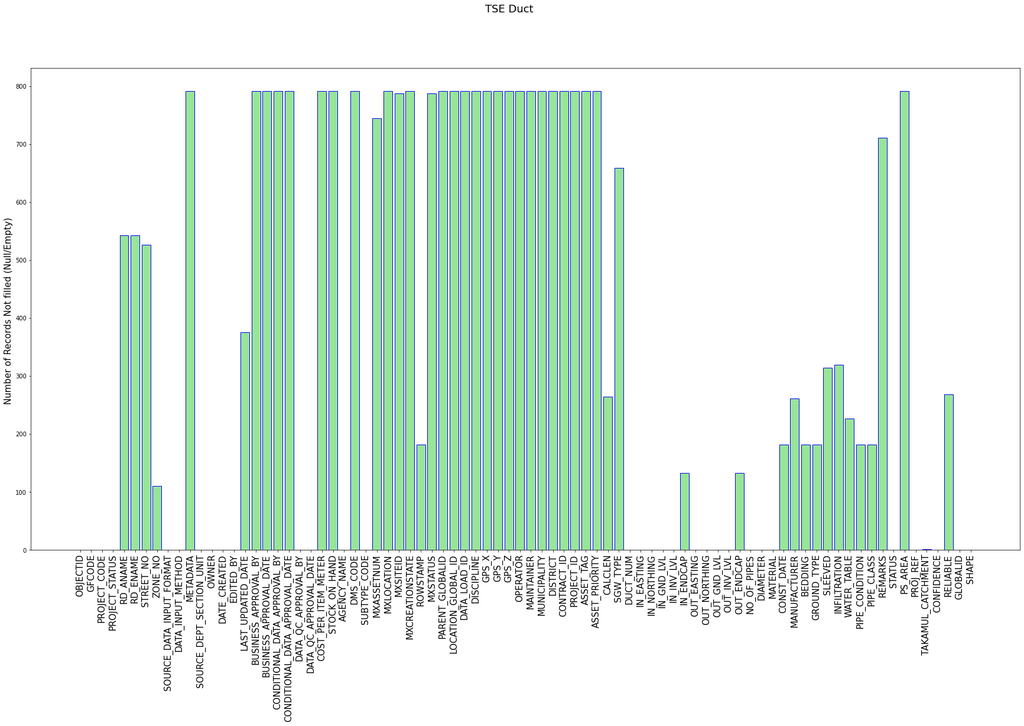

```python
x = TSE_Duct.columns
y = TSE_Duct.isnull().sum()
plt.figure(figsize=(30,15))
plt.bar(x, y, color= (0.2,0.8,0.2,0.5),  edgecolor='Blue')
plt.suptitle("TSE Duct", fontsize=18)
plt.ylabel("Number of Records Not filled (Null/Empty) ", fontsize=15)
plt.xticks(rotation=90, fontsize=15)
plt.show()
```

### 7. Treated Effluent Pipe

Treated Effluent Pipe feature class has:

[output not shown]

```python
Treated_Effluent_Pipe = pd.DataFrame.spatial.from_featureclass(r"C:\Users\esd_kgathogo\AppData\Roaming\ESRI\Desktop10.7\ArcCatalog\PWAROADS.sde\SDE.DRG_TREATED_EFFLUENT_NETWORK\SDE.TELNPPIP")
Treated_Effluent_Pipe.head(2)
```

|  | OBJECTID | GFCODE | PROJECT_CODE | PROJECT_STATUS | RD_ANAME | RD_ENAME | STREET_NO | ZONE_NO | FEATURE_REMARKS | SOURCE_DATA_INPUT_FORMAT | DATA_INPUT_METHOD | METADATA | SOURCE_DEPT_SECTION_UNIT | OWNER | DATE_CREATED | EDITED_BY | LAST_UPDATED_DATE | BUSINESS_APPROVAL_BY | BUSINESS_APPROVAL_DATE | CONDITIONAL_DATA_APPROVAL_BY | CONDITIONAL_DATA_APPROVAL_DATE | DATA_QC_APPROVAL_BY | DATA_QC_APPROVAL_DATE | COST_PER_ITEM_METER | STOCK_ON_HAND | AGENCY_NAME | DMS_CODE | FM_GND_LVL | TO_GND_LVL | … |
| --- | --- | --- | --- | --- | --- | --- | --- | --- | --- | --- | --- | --- | --- | --- | --- | --- | --- | --- | --- | --- | --- | --- | --- | --- | --- | --- | --- | --- | --- | --- |
| 0 | 2160210 | TELNPPIP | CP01 | As Built | None | None | NaN | 69.0 | None | Excel | Manual | None | Drainage O&M | O&M Drainage | 2021-01-05 | ES | 2021-01-05 | None | NaT | None | NaT | ES | 2021-01-05 | NaN | None | Ashghal | None | 3.149 | 3.398 | … |
| 1 | 2159190 | TELNPPIP | CP01 | As Built | None | None | NaN | 69.0 | None | Excel | Manual | None | Drainage O&M | O&M Drainage | 2021-01-05 | ES | 2021-01-05 | None | NaT | None | NaT | ES | 2021-01-05 | NaN | None | Ashghal | None | 3.710 | 3.710 | … |

2 rows × 91 columns

```python
Treated_Effluent_Pipe.shape
```

```
(84838, 91)
```

```python
Treated_Effluent_Pipe_null = pd.DataFrame(Treated_Effluent_Pipe.isnull().sum())
Treated_Effluent_Pipe_null
```

|  | 0 |
| --- | --- |
| OBJECTID | 0 |
| GFCODE | 23 |
| PROJECT_CODE | 2369 |
| PROJECT_STATUS | 11440 |
| RD_ANAME | 78524 |
| ... | ... |
| DISTRICT | 84742 |
| CONTRACT_ID | 84683 |
| PROJECT_ID | 84742 |
| ASSET_PRIORITY | 84838 |
| SHAPE | 0 |

91 rows × 1 columns

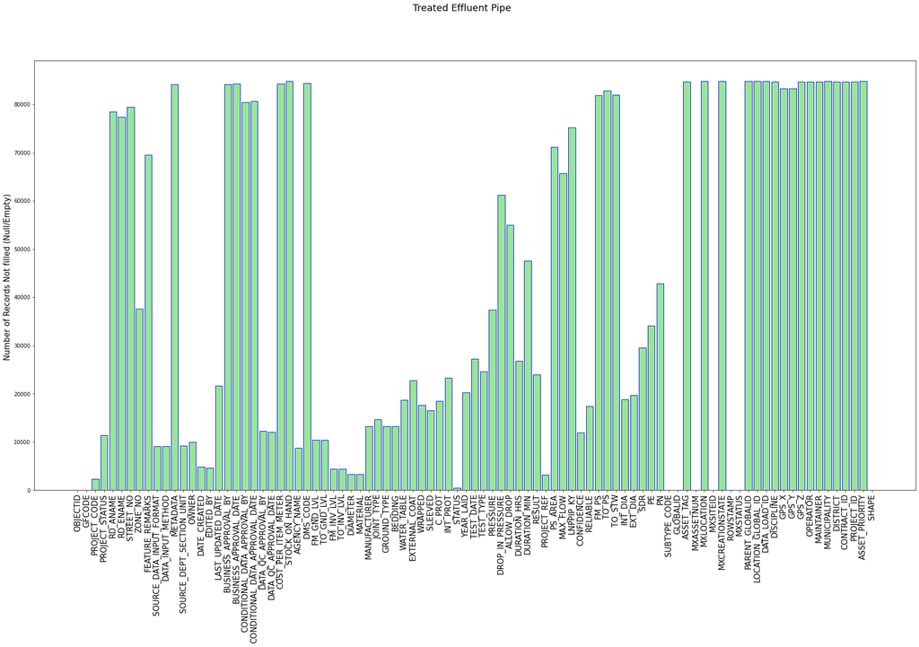

```python
x = Treated_Effluent_Pipe.columns
y = Treated_Effluent_Pipe.isnull().sum()
plt.figure(figsize=(30,15))
plt.bar(x, y, color= (0.2,0.8,0.2,0.5),  edgecolor='Blue')
plt.suptitle(" Treated Effluent Pipe", fontsize=18)
plt.ylabel("Number of Records Not filled (Null/Empty) ", fontsize=15)
plt.xticks(rotation=90, fontsize=15)
plt.show()
```

### 8. TSE Stub Pipe

TSE Stub Pipe feature class has:

[output not shown]

```python
TSE_Stub_Pipe = pd.DataFrame.spatial.from_featureclass(r"C:\Users\esd_kgathogo\AppData\Roaming\ESRI\Desktop10.7\ArcCatalog\PWAROADS.sde\SDE.DRG_TREATED_EFFLUENT_NETWORK\SDE.TELNSTUB")
TSE_Stub_Pipe.head(2)
```

|  | OBJECTID | GFCODE | PROJECT_CODE | PROJECT_STATUS | RD_ANAME | RD_ENAME | STREET_NO | ZONE_NO | FEATURE_REMARKS | SOURCE_DATA_INPUT_FORMAT | DATA_INPUT_METHOD | METADATA | SOURCE_DEPT_SECTION_UNIT | OWNER | DATE_CREATED | EDITED_BY | LAST_UPDATED_DATE | BUSINESS_APPROVAL_BY | BUSINESS_APPROVAL_DATE | CONDITIONAL_DATA_APPROVAL_BY | CONDITIONAL_DATA_APPROVAL_DATE | DATA_QC_APPROVAL_BY | DATA_QC_APPROVAL_DATE | COST_PER_ITEM_METER | STOCK_ON_HAND | AGENCY_NAME | DMS_CODE | FM_GND_LVL | TO_GND_LVL | … |
| --- | --- | --- | --- | --- | --- | --- | --- | --- | --- | --- | --- | --- | --- | --- | --- | --- | --- | --- | --- | --- | --- | --- | --- | --- | --- | --- | --- | --- | --- | --- |
| 0 | 22387 | TELNSTUB | IA 13/14 C014ST | As Built Yet to be Approved | الجنوب | Al Janoub | 416.0 | 90.0 | Node - 400 To Node - 398 | Excel | Manual | None | Drainage O&M | O&M Drainage | 2019-12-12 14:40:11 | ES | 2019-12-12 14:40:15 | None | None | None | NaT | ES | 2019-12-12 14:40:20 | None | None | Ashghal | None | 5.36 | 5.28 | … |
| 1 | 22384 | TELNSTUB | IA 13/14 C014ST | As Built Yet to be Approved | مستشفى الوكرة | Al Wakra Hospital | 760.0 | 90.0 | 90/760/02/DC/01/GV To Node - 395 | Excel | Manual | None | Drainage O&M | O&M Drainage | 2019-12-12 14:40:11 | ES | 2019-12-12 14:40:15 | None | None | None | NaT | ES | 2019-12-12 14:40:20 | None | None | Ashghal | None | 5.48 | 5.48 | … |

2 rows × 91 columns

```python
TSE_Stub_Pipe.shape
```

```
(441, 91)
```

```python
TSE_Stub_Pipe_null = pd.DataFrame(TSE_Stub_Pipe.isnull().sum())
TSE_Stub_Pipe_null
```

|  | 0 |
| --- | --- |
| OBJECTID | 0 |
| GFCODE | 0 |
| PROJECT_CODE | 0 |
| PROJECT_STATUS | 0 |
| RD_ANAME | 318 |
| ... | ... |
| DISTRICT | 441 |
| CONTRACT_ID | 441 |
| PROJECT_ID | 441 |
| ASSET_PRIORITY | 441 |
| SHAPE | 0 |

91 rows × 1 columns

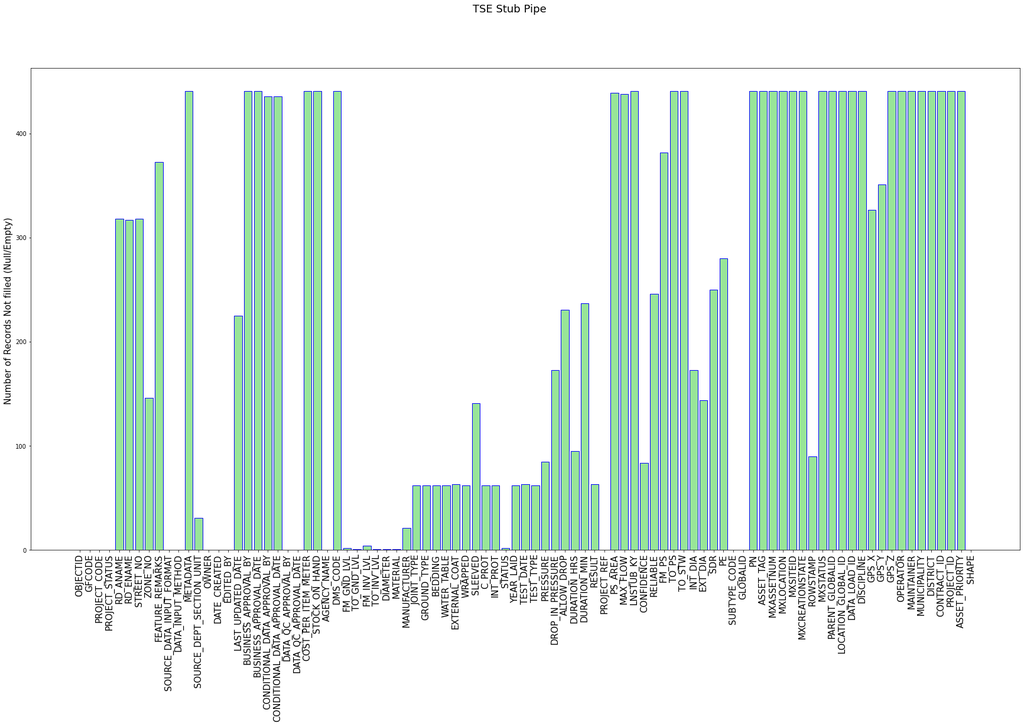

```python
x = TSE_Stub_Pipe.columns
y = TSE_Stub_Pipe.isnull().sum()
plt.figure(figsize=(30,15))
plt.bar(x, y, color= (0.2,0.8,0.2,0.5),  edgecolor='Blue')
plt.suptitle("TSE Stub Pipe", fontsize=18)
plt.ylabel("Number of Records Not filled (Null/Empty) ", fontsize=15)
plt.xticks(rotation=90, fontsize=15)
plt.show()
```

### 9. TSE Cover

TSE Cover feature class has:

```
    •   Attribute Fields (Columns): 75
    •   Total Records (Rows): 2,674
```

```python
TSE_Cover = pd.DataFrame.spatial.from_featureclass(r"C:\Users\esd_kgathogo\AppData\Roaming\ESRI\Desktop10.7\ArcCatalog\PWAROADS.sde\SDE.DRG_TREATED_EFFLUENT_NETWORK\SDE.TENDCOVR")
TSE_Cover.head(2)
```

|  | OBJECTID | GFCODE | PROJECT_CODE | PROJECT_STATUS | RD_ANAME | RD_ENAME | STREET_NO | ZONE_NO | SOURCE_DATA_INPUT_FORMAT | DATA_INPUT_METHOD | METADATA | SOURCE_DEPT_SECTION_UNIT | OWNER | DATE_CREATED | EDITED_BY | LAST_UPDATED_DATE | BUSINESS_APPROVAL_BY | BUSINESS_APPROVAL_DATE | CONDITIONAL_DATA_APPROVAL_BY | CONDITIONAL_DATA_APPROVAL_DATE | DATA_QC_APPROVAL_BY | DATA_QC_APPROVAL_DATE | COST_PER_ITEM_METER | STOCK_ON_HAND | AGENCY_NAME | DMS_CODE | NDFMCH_KY | EASTING | NORTHING | … |
| --- | --- | --- | --- | --- | --- | --- | --- | --- | --- | --- | --- | --- | --- | --- | --- | --- | --- | --- | --- | --- | --- | --- | --- | --- | --- | --- | --- | --- | --- | --- |
| 0 | 17 | TENDWOCR | IA 2016 C 033 G | As Built | None | None | NaN | NaN | Excel | Automation | None | Drainage O&M | O&M Drainage | 2020-04-07 | IW | NaT | None | None | None | None | IW/EA | 2020-04-12 | None | None | Ashghal | None | None | 237777.865 | 377687.081 | … |
| 1 | 18 | TENDARCR | IA 2016 C 033 G | As Built | None | None | NaN | NaN | Excel | Automation | None | Drainage O&M | O&M Drainage | 2020-04-07 | IW | NaT | None | None | None | None | IW/EA | 2020-04-12 | None | None | Ashghal | None | None | 237601.737 | 377638.043 | … |

```python
TSE_Cover.shape
```

```
(2674, 75)
```

```python
TSE_Cover_null = pd.DataFrame(TSE_Cover.isnull().sum())
TSE_Cover_null
```

|  | 0 |
| --- | --- |
| OBJECTID | 0 |
| GFCODE | 0 |
| PROJECT_CODE | 106 |
| PROJECT_STATUS | 106 |
| RD_ANAME | 2536 |
| ... | ... |
| TAKAMUL_CATCHMENT | 583 |
| CONFIDENCE | 0 |
| RELIABLE | 538 |
| GLOBALID | 0 |
| SHAPE | 0 |

75 rows × 1 columns

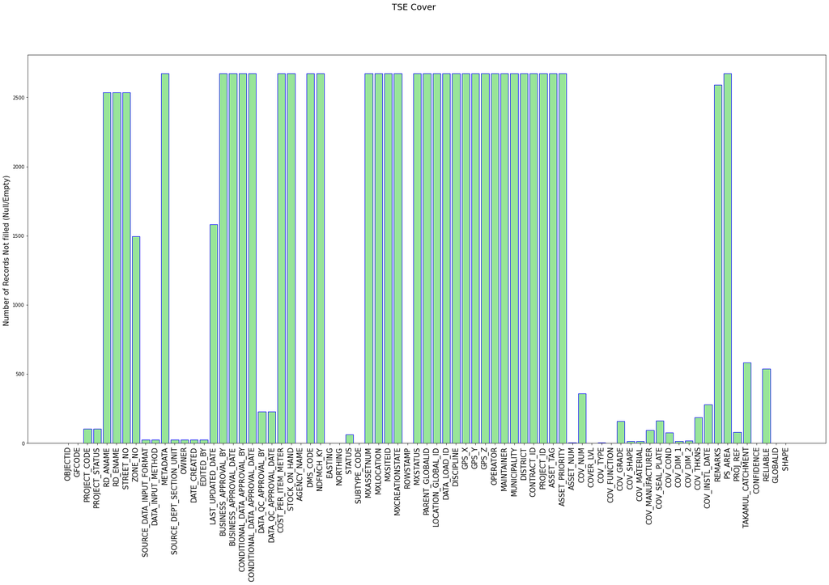

```python
x = TSE_Cover.columns
y = TSE_Cover.isnull().sum()
plt.figure(figsize=(30,15))
plt.bar(x, y, color= (0.2,0.8,0.2,0.5),  edgecolor='Blue')
plt.suptitle("TSE Cover", fontsize=18)
plt.ylabel("Number of Records Not filled (Null/Empty) ", fontsize=15)
plt.xticks(rotation=90, fontsize=15)
plt.show()
```

### 10. TSE Distribution Chamber Corner

TSE Distribution Chamber Corner feature class has:

[output not shown]

```python
TSE_Distribution_Chamber_Corner = pd.DataFrame.spatial.from_featureclass(r"C:\Users\esd_kgathogo\AppData\Roaming\ESRI\Desktop10.7\ArcCatalog\PWAROADS.sde\SDE.DRG_TREATED_EFFLUENT_NETWORK\SDE.TENDDSCR")
TSE_Distribution_Chamber_Corner.head(2)
```

|  | OBJECTID | GFCODE | PROJECT_CODE | PROJECT_STATUS | RD_ANAME | RD_ENAME | STREET_NO | ZONE_NO | FEATURE_REMARKS | SOURCE_DATA_INPUT_FORMAT | DATA_INPUT_METHOD | METADATA | SOURCE_DEPT_SECTION_UNIT | OWNER | DATE_CREATED | EDITED_BY | LAST_UPDATED_DATE | BUSINESS_APPROVAL_BY | BUSINESS_APPROVAL_DATE | CONDITIONAL_DATA_APPROVAL_BY | CONDITIONAL_DATA_APPROVAL_DATE | DATA_QC_APPROVAL_BY | DATA_QC_APPROVAL_DATE | COST_PER_ITEM_METER | STOCK_ON_HAND | AGENCY_NAME | DMS_CODE | NDDSVC_KY | PROJECT_REF | … |
| --- | --- | --- | --- | --- | --- | --- | --- | --- | --- | --- | --- | --- | --- | --- | --- | --- | --- | --- | --- | --- | --- | --- | --- | --- | --- | --- | --- | --- | --- | --- |
| 0 | 265434 | TENDDSCR | IA 11/12 C 159 G | As Built Yet to be Approved | None | None | NaN | 74.0 | Asset captured for beneficiary purpose only (R... | DWG | Digitization | None | Drainage O&M | O&M Drainage | 2020-10-12 | VV | 2020-10-15 09:04:31 | None | None | None | NaT | VV/ES | 2020-10-12 | None | None | Ashghal | None | NaN | C2012/28 | … |
| 1 | 265429 | TENDDSCR | IA 11/12 C 159 G | As Built Yet to be Approved | None | None | NaN | 70.0 | Asset captured for beneficiary purpose only (R... | DWG | Digitization | None | Drainage O&M | O&M Drainage | 2020-10-12 | VV | 2020-10-15 09:04:31 | None | None | None | NaT | VV/ES | 2020-10-12 | None | None | Ashghal | None | NaN | C2012/28 | … |

```python
TSE_Distribution_Chamber_Corner.shape
```

```
(11955, 58)
```

```python
TSE_Distribution_Chamber_Corner_null = pd.DataFrame(TSE_Distribution_Chamber_Corner.isnull().sum())
```

```python
TSE_Distribution_Chamber_Corner_null
```

|  | 0 |
| --- | --- |
| OBJECTID | 0 |
| GFCODE | 0 |
| PROJECT_CODE | 436 |
| PROJECT_STATUS | 488 |
| RD_ANAME | 9581 |
| RD_ENAME | 9551 |
| STREET_NO | 9562 |
| ZONE_NO | 3964 |
| FEATURE_REMARKS | 7598 |
| SOURCE_DATA_INPUT_FORMAT | 87 |
| DATA_INPUT_METHOD | 87 |
| METADATA | 11820 |
| SOURCE_DEPT_SECTION_UNIT | 167 |
| OWNER | 17 |
| DATE_CREATED | 58 |
| EDITED_BY | 0 |
| LAST_UPDATED_DATE | 3713 |
| BUSINESS_APPROVAL_BY | 11955 |
| BUSINESS_APPROVAL_DATE | 11955 |
| CONDITIONAL_DATA_APPROVAL_BY | 11790 |
| CONDITIONAL_DATA_APPROVAL_DATE | 11720 |
| DATA_QC_APPROVAL_BY | 309 |
| DATA_QC_APPROVAL_DATE | 327 |
| COST_PER_ITEM_METER | 11955 |
| STOCK_ON_HAND | 11955 |
| AGENCY_NAME | 0 |
| DMS_CODE | 11820 |
| NDDSVC_KY | 11885 |
| PROJECT_REF | 1064 |
| VC_OLD | 5 |
| SURV_DATE | 4260 |
| GROUND_LVL | 660 |
| CONST_DATE | 3962 |
| SUBTYPE_CODE | 0 |
| GLOBALID | 0 |
| STATUS | 261 |
| ASSET_TAG | 11955 |
| MXASSETNUM | 11955 |
| MXLOCATION | 11955 |
| MXSITEID | 11955 |
| MXCREATIONSTATE | 11955 |
| ROWSTAMP | 4669 |
| MXSTATUS | 11955 |
| PARENT_GLOBALID | 11955 |
| LOCATION_GLOBAL_ID | 11955 |
| DATA_LOAD_ID | 11955 |
| DISCIPLINE | 11955 |
| GPS_X | 11767 |
| GPS_Y | 11767 |
| GPS_Z | 11955 |
| OPERATOR | 11955 |
| MAINTAINER | 11955 |
| MUNICIPALITY | 11955 |
| DISTRICT | 11955 |
| CONTRACT_ID | 11955 |
| PROJECT_ID | 11955 |
| ASSET_PRIORITY | 11955 |
| SHAPE | 0 |

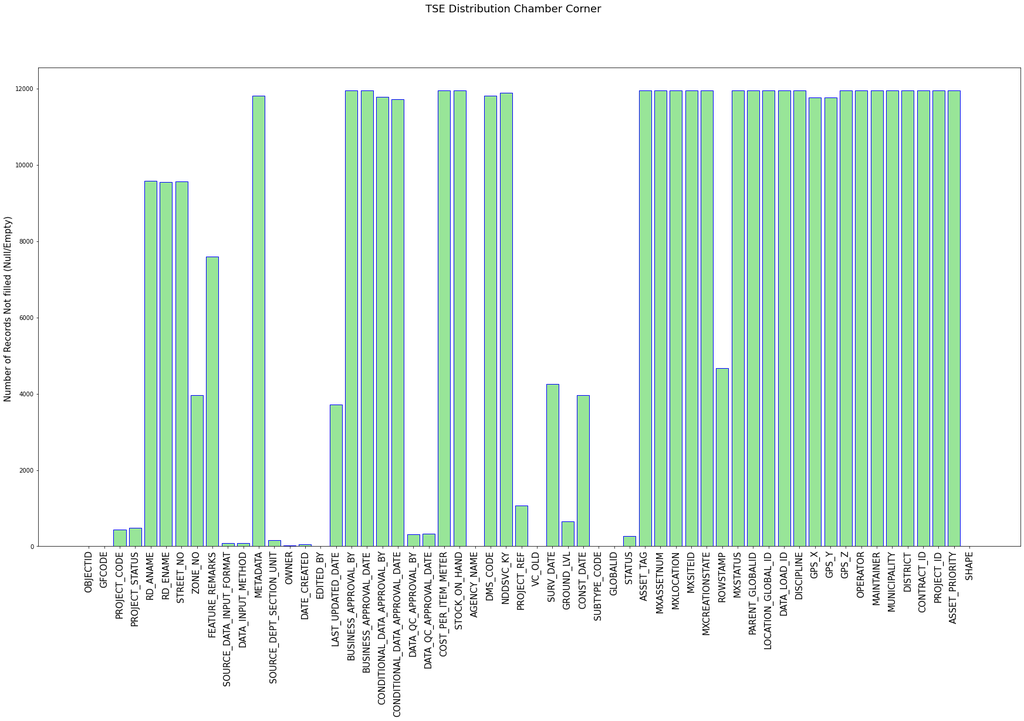

```python
x = TSE_Distribution_Chamber_Corner.columns
y = TSE_Distribution_Chamber_Corner.isnull().sum()
plt.figure(figsize=(30,15))
plt.bar(x, y, color= (0.2,0.8,0.2,0.5),  edgecolor='Blue')
plt.suptitle("TSE Distribution Chamber Corner", fontsize=18)
plt.ylabel("Number of Records Not filled (Null/Empty) ", fontsize=15)
plt.xticks(rotation=90, fontsize=15)
plt.show()
```

### 11. TSE Distribution Chamber

TSE Distribution Chamber feature class has:

[output not shown]

```python
TSE_Distribution_Chamber = pd.DataFrame.spatial.from_featureclass(r"C:\Users\esd_kgathogo\AppData\Roaming\ESRI\Desktop10.7\ArcCatalog\PWAROADS.sde\SDE.DRG_TREATED_EFFLUENT_NETWORK\SDE.TENDDSVC")
TSE_Distribution_Chamber.head(2)
```

|  | OBJECTID | GFCODE | PROJECT_CODE | PROJECT_STATUS | RD_ANAME | RD_ENAME | STREET_NO | ZONE_NO | FEATURE_REMARKS | SOURCE_DATA_INPUT_FORMAT | DATA_INPUT_METHOD | METADATA | SOURCE_DEPT_SECTION_UNIT | OWNER | DATE_CREATED | EDITED_BY | LAST_UPDATED_DATE | BUSINESS_APPROVAL_BY | BUSINESS_APPROVAL_DATE | CONDITIONAL_DATA_APPROVAL_BY | CONDITIONAL_DATA_APPROVAL_DATE | DATA_QC_APPROVAL_BY | DATA_QC_APPROVAL_DATE | COST_PER_ITEM_METER | STOCK_ON_HAND | AGENCY_NAME | DMS_CODE | NDDSVC_KY | PROJECT_REF | … |
| --- | --- | --- | --- | --- | --- | --- | --- | --- | --- | --- | --- | --- | --- | --- | --- | --- | --- | --- | --- | --- | --- | --- | --- | --- | --- | --- | --- | --- | --- | --- |
| 0 | 196430 | TENDDSVC | IA 10/11 C 117 G | As Built | None | None | NaN | 66.0 | None | Excel | Automation | None | Drainage O&M | O&M Drainage | 2021-08-10 | VV | 2021-08-30 | None | NaT | None | NaT | VV/ES | 2021-08-10 | None | None | Ashghal | None | NaN | C2012/18 | … |
| 1 | 196574 | TENDDSVC | IA 14/15 C 014 ST | As Built | None | None | NaN | 70.0 | None | Excel | Manual | None | Drainage O&M | O&M Drainage | 2022-01-23 | ES | 2022-01-23 | None | NaT | None | NaT | ES | 2022-01-23 | None | None | Ashghal | None | NaN | C2017/113 | … |

2 rows × 108 columns

```python
TSE_Distribution_Chamber.shape
```

```
(5461, 108)
```

```python
TSE_Distribution_Chamber_null = pd.DataFrame(TSE_Distribution_Chamber.isnull().sum())
```

```python
TSE_Distribution_Chamber_null
```

|  | 0 |
| --- | --- |
| OBJECTID | 0 |
| GFCODE | 0 |
| PROJECT_CODE | 158 |
| PROJECT_STATUS | 1612 |
| RD_ANAME | 4796 |
| ... | ... |
| DISTRICT | 5461 |
| CONTRACT_ID | 5461 |
| PROJECT_ID | 5461 |
| ASSET_PRIORITY | 5460 |
| SHAPE | 0 |

108 rows × 1 columns

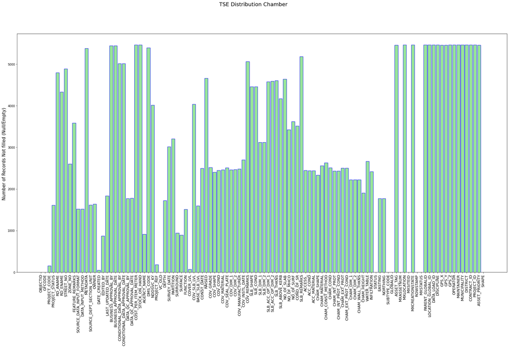

```python
x = TSE_Distribution_Chamber.columns
y = TSE_Distribution_Chamber.isnull().sum()
plt.figure(figsize=(30,15))
plt.bar(x, y, color= (0.2,0.8,0.2,0.5),  edgecolor='Blue')
plt.suptitle("TSE Distribution Chamber ", fontsize=18)
plt.ylabel("Number of Records Not filled (Null/Empty) ", fontsize=15)
plt.xticks(rotation=90, fontsize=13)
plt.show()
```

### 12. Fire Hydrant

Fire Hydrant feature class has:

[output not shown]

```python
Fire_Hydrant = pd.DataFrame.spatial.from_featureclass(r"C:\Users\esd_kgathogo\AppData\Roaming\ESRI\Desktop10.7\ArcCatalog\PWAROADS.sde\SDE.DRG_TREATED_EFFLUENT_NETWORK\SDE.TENDFIHD")
Fire_Hydrant.head(1)
```

|  | OBJECTID | GFCODE | PROJECT_CODE | PROJECT_STATUS | RD_ANAME | RD_ENAME | STREET_NO | ZONE_NO | FEATURE_REMARKS | SOURCE_DATA_INPUT_FORMAT | DATA_INPUT_METHOD | METADATA | SOURCE_DEPT_SECTION_UNIT | OWNER | DATE_CREATED | EDITED_BY | LAST_UPDATED_DATE | BUSINESS_APPROVAL_BY | BUSINESS_APPROVAL_DATE | CONDITIONAL_DATA_APPROVAL_BY | CONDITIONAL_DATA_APPROVAL_DATE | DATA_QC_APPROVAL_BY | DATA_QC_APPROVAL_DATE | COST_PER_ITEM_METER | STOCK_ON_HAND | AGENCY_NAME | DMS_CODE | FIRE_HYDRA | EASTING | … |
| --- | --- | --- | --- | --- | --- | --- | --- | --- | --- | --- | --- | --- | --- | --- | --- | --- | --- | --- | --- | --- | --- | --- | --- | --- | --- | --- | --- | --- | --- | --- |
| 0 | 15306 | TENDFIHD | IA 12/13 C060 ST | As Built Yet to be Approved | None | None | NaN | 92.0 | None | A | Automation | None | Drainage O&M | O&M Drainage | 2020-09-13 | VV | 2020-09-20 11:58:25 | None | None | None | NaT | VV/ES | 2020-09-20 11:58:36 | None | None | Ashghal | None | 92/313/NOH-C1/003/FH | 234185.304 | … |

```python
Fire_Hydrant.shape
```

```
(317, 58)
```

```python
Fire_Hydrant_null = pd.DataFrame(Fire_Hydrant.isnull().sum())
```

```python
Fire_Hydrant_null
```

|  | 0 |
| --- | --- |
| OBJECTID | 0 |
| GFCODE | 0 |
| PROJECT_CODE | 165 |
| PROJECT_STATUS | 165 |
| RD_ANAME | 303 |
| RD_ENAME | 248 |
| STREET_NO | 310 |
| ZONE_NO | 269 |
| FEATURE_REMARKS | 148 |
| SOURCE_DATA_INPUT_FORMAT | 0 |
| DATA_INPUT_METHOD | 150 |
| METADATA | 317 |
| SOURCE_DEPT_SECTION_UNIT | 150 |
| OWNER | 150 |
| DATE_CREATED | 152 |
| EDITED_BY | 101 |
| LAST_UPDATED_DATE | 109 |
| BUSINESS_APPROVAL_BY | 317 |
| BUSINESS_APPROVAL_DATE | 317 |
| CONDITIONAL_DATA_APPROVAL_BY | 260 |
| CONDITIONAL_DATA_APPROVAL_DATE | 260 |
| DATA_QC_APPROVAL_BY | 209 |
| DATA_QC_APPROVAL_DATE | 208 |
| COST_PER_ITEM_METER | 317 |
| STOCK_ON_HAND | 317 |
| AGENCY_NAME | 0 |
| DMS_CODE | 317 |
| FIRE_HYDRA | 1 |
| EASTING | 0 |
| NORTHING | 0 |
| GROUND_LVL | 68 |
| FIRE_HYDRANT_TYPE | 41 |
| GLOBALID | 0 |
| NDHYDRT_KY | 317 |
| SUBTYPE_CODE | 0 |
| STATUS | 0 |
| ASSET_TAG | 159 |
| MXASSETNUM | 0 |
| MXLOCATION | 317 |
| MXSITEID | 0 |
| MXCREATIONSTATE | 317 |
| ROWSTAMP | 0 |
| MXSTATUS | 0 |
| PARENT_GLOBALID | 317 |
| LOCATION_GLOBAL_ID | 317 |
| DATA_LOAD_ID | 317 |
| DISCIPLINE | 317 |
| GPS_X | 317 |
| GPS_Y | 317 |
| GPS_Z | 317 |
| OPERATOR | 317 |
| MAINTAINER | 317 |
| MUNICIPALITY | 317 |
| DISTRICT | 317 |
| CONTRACT_ID | 317 |
| PROJECT_ID | 316 |
| ASSET_PRIORITY | 317 |
| SHAPE | 0 |

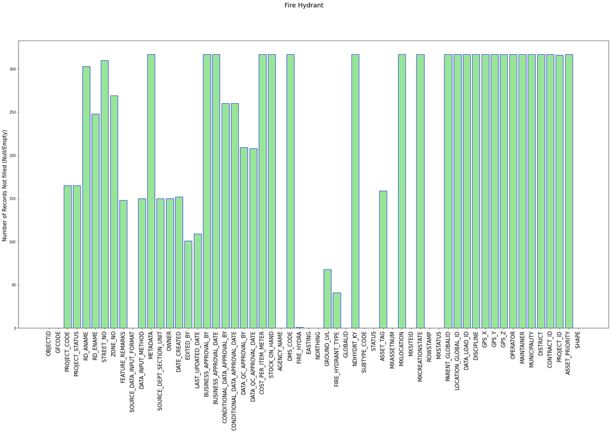

```python
x = Fire_Hydrant.columns
y = Fire_Hydrant.isnull().sum()
plt.figure(figsize=(30,15))
plt.bar(x, y, color= (0.2,0.8,0.2,0.5),  edgecolor='Blue')
plt.suptitle("Fire Hydrant", fontsize=18)
plt.ylabel("Number of Records Not filled (Null/Empty) ", fontsize=15)
plt.xticks(rotation=90, fontsize=15)
plt.show()
```

### 13. TSE Fittings

TSE Fittings feature class has:

```
    •   Attribute Fields (Columns): 67
    •   Total Records (Rows): 8,985
```

```python
TSE_Fittings = pd.DataFrame.spatial.from_featureclass(r"C:\Users\esd_kgathogo\AppData\Roaming\ESRI\Desktop10.7\ArcCatalog\PWAROADS.sde\SDE.DRG_TREATED_EFFLUENT_NETWORK\SDE.TENDFITT")
TSE_Fittings.head(2)
```

|  | OBJECTID | GFCODE | PROJECT_CODE | PROJECT_STATUS | RD_ANAME | RD_ENAME | STREET_NO | ZONE_NO | SOURCE_DATA_INPUT_FORMAT | DATA_INPUT_METHOD | METADATA | SOURCE_DEPT_SECTION_UNIT | OWNER | DATE_CREATED | EDITED_BY | LAST_UPDATED_DATE | BUSINESS_APPROVAL_BY | BUSINESS_APPROVAL_DATE | CONDITIONAL_DATA_APPROVAL_BY | CONDITIONAL_DATA_APPROVAL_DATE | DATA_QC_APPROVAL_BY | DATA_QC_APPROVAL_DATE | COST_PER_ITEM_METER | STOCK_ON_HAND | AGENCY_NAME | DMS_CODE | NDFMCH_KY | EASTING | NORTHING | … |
| --- | --- | --- | --- | --- | --- | --- | --- | --- | --- | --- | --- | --- | --- | --- | --- | --- | --- | --- | --- | --- | --- | --- | --- | --- | --- | --- | --- | --- | --- | --- |
| 0 | 18 | TENDFITT | IA 2016 C 033 G | As Built | None | None | NaN | NaN | Excel | Automation | None | Drainage O&M | O&M Drainage | 2020-04-07 | IW | NaT | None | None | None | None | IW/EA | 2020-04-12 | None | None | Ashghal | None | None | 236930.566 | 379432.038 | … |
| 1 | 19 | TENDFITT | IA 2016 C 033 G | As Built | None | None | NaN | NaN | Excel | Automation | None | Drainage O&M | O&M Drainage | 2020-04-07 | IW | NaT | None | None | None | None | IW/EA | 2020-04-12 | None | None | Ashghal | None | None | 236947.750 | 379469.399 | … |

```python
TSE_Fittings.shape
```

```
(8985, 67)
```

```python
TSE_Fittings_null = pd.DataFrame(TSE_Fittings.isnull().sum())
```

```python
TSE_Fittings_null
```

|  | 0 |
| --- | --- |
| OBJECTID | 0 |
| GFCODE | 0 |
| PROJECT_CODE | 505 |
| PROJECT_STATUS | 3816 |
| RD_ANAME | 8575 |
| ... | ... |
| TAKAMUL_CATCHMENT | 3541 |
| CONFIDENCE | 530 |
| RELIABLE | 1142 |
| GLOBALID | 0 |
| SHAPE | 0 |

67 rows × 1 columns

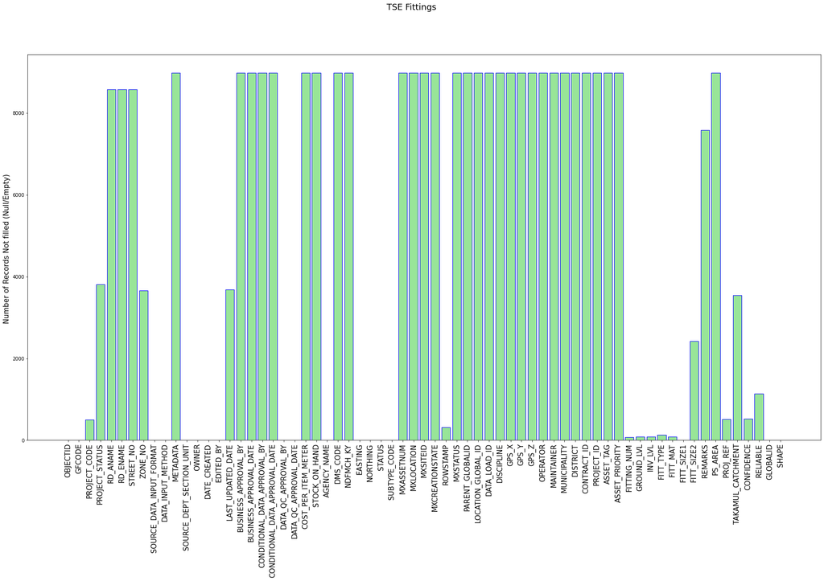

```python
x = TSE_Fittings.columns
y = TSE_Fittings.isnull().sum()
plt.figure(figsize=(30,15))
plt.bar(x, y, color= (0.2,0.8,0.2,0.5),  edgecolor='Blue')
plt.suptitle("TSE Fittings", fontsize=18)
plt.ylabel("Number of Records Not filled (Null/Empty) ", fontsize=15)
plt.xticks(rotation=90, fontsize=15)
plt.show()
```

### 14. TSE Flow Meter Chamber

TSE Flow Meter Chamber feature class has:

[output not shown]

```python
TSE_Flow_Meter_Chamber = pd.DataFrame.spatial.from_featureclass(r"C:\Users\esd_kgathogo\AppData\Roaming\ESRI\Desktop10.7\ArcCatalog\PWAROADS.sde\SDE.DRG_TREATED_EFFLUENT_NETWORK\SDE.TENDFMCH")
TSE_Flow_Meter_Chamber.head(2)
```

|  | OBJECTID | GFCODE | PROJECT_CODE | PROJECT_STATUS | RD_ANAME | RD_ENAME | STREET_NO | ZONE_NO | FEATURE_REMARKS | SOURCE_DATA_INPUT_FORMAT | DATA_INPUT_METHOD | METADATA | SOURCE_DEPT_SECTION_UNIT | OWNER | DATE_CREATED | EDITED_BY | LAST_UPDATED_DATE | BUSINESS_APPROVAL_BY | BUSINESS_APPROVAL_DATE | CONDITIONAL_DATA_APPROVAL_BY | CONDITIONAL_DATA_APPROVAL_DATE | DATA_QC_APPROVAL_BY | DATA_QC_APPROVAL_DATE | COST_PER_ITEM_METER | STOCK_ON_HAND | AGENCY_NAME | DMS_CODE | NDFMCH_KY | EASTING | … |
| --- | --- | --- | --- | --- | --- | --- | --- | --- | --- | --- | --- | --- | --- | --- | --- | --- | --- | --- | --- | --- | --- | --- | --- | --- | --- | --- | --- | --- | --- | --- |
| 0 | 14377 | TENDFMCH | DTC0045 | AS BUILT | None | None | NaN | NaN | None | DWG | Digitization | None | None | None | 2000-06-01 | ERIC | NaT | None | None | None | None | None | NaT | None | None | Ashghal | None | 17.0 | 229188.737 | … |
| 1 | 14374 | TENDFMCH | DTC0045 | AS BUILT | None | None | NaN | NaN | None | DWG | Digitization | None | None | None | 2000-06-01 | ERIC | NaT | None | None | None | None | None | NaT | None | None | Ashghal | None | 83.0 | 228795.951 | … |

2 rows × 105 columns

```python
TSE_Flow_Meter_Chamber.shape
```

```
(227, 105)
```

```python
TSE_Flow_Meter_Chamber_null = pd.DataFrame(TSE_Flow_Meter_Chamber.isnull().sum())
```

```python
TSE_Flow_Meter_Chamber_null
```

|  | 0 |
| --- | --- |
| OBJECTID | 0 |
| GFCODE | 0 |
| PROJECT_CODE | 13 |
| PROJECT_STATUS | 7 |
| RD_ANAME | 224 |
| ... | ... |
| DISTRICT | 227 |
| CONTRACT_ID | 227 |
| PROJECT_ID | 227 |
| ASSET_PRIORITY | 226 |
| SHAPE | 0 |

105 rows × 1 columns

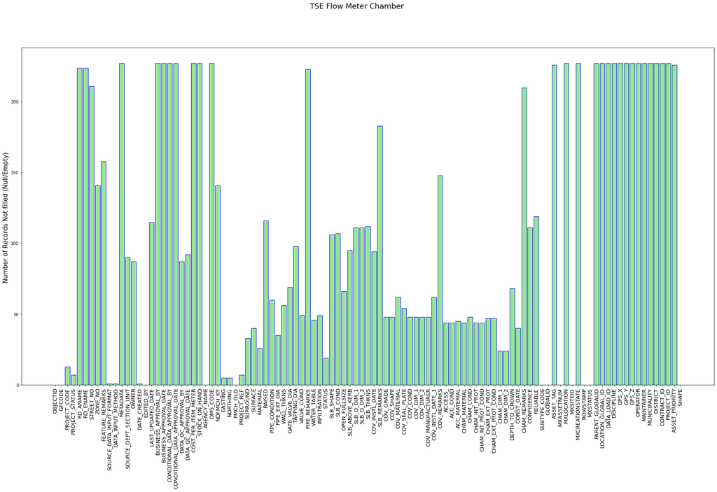

```python
x = TSE_Flow_Meter_Chamber.columns
y = TSE_Flow_Meter_Chamber.isnull().sum()
plt.figure(figsize=(30,15))
plt.bar(x, y, color= (0.2,0.8,0.2,0.5),  edgecolor='Blue')
plt.suptitle("TSE Flow Meter Chamber", fontsize=18)
plt.ylabel("Number of Records Not filled (Null/Empty) ", fontsize=15)
plt.xticks(rotation=90, fontsize=13)
plt.show()
```

### 15. TSE Deep Injection Well

TSE Deep Injection Well feature class has:

```
    •   Attribute Fields (Columns): 68
    •   Total Records (Rows): 137
```

```python
TSE_Deep_Injection_Well = pd.DataFrame.spatial.from_featureclass(r"C:\Users\esd_kgathogo\AppData\Roaming\ESRI\Desktop10.7\ArcCatalog\PWAROADS.sde\SDE.DRG_TREATED_EFFLUENT_NETWORK\SDE.TENDINJW")
TSE_Deep_Injection_Well.head(2)
```

|  | OBJECTID | GFCODE | PROJECT_REF | PROJECT_CODE | PROJECT_STATUS | RD_ANAME | RD_ENAME | STREET_NO | ZONE_NO | FEATURE_REMARKS | SOURCE_DATA_INPUT_FORMAT | DATA_INPUT_METHOD | METADATA | SOURCE_DEPT_SECTION_UNIT | OWNER | DATE_CREATED | EDITED_BY | LAST_UPDATED_DATE | BUSINESS_APPROVAL_BY | BUSINESS_APPROVAL_DATE | CONDITIONAL_DATA_APPROVAL_BY | CONDITIONAL_DATA_APPROVAL_DATE | DATA_QC_APPROVAL_BY | DATA_QC_APPROVAL_DATE | COST_PER_ITEM_METER | STOCK_ON_HAND | AGENCY_NAME | DMS_CODE | NETWORK_TYPE | … |
| --- | --- | --- | --- | --- | --- | --- | --- | --- | --- | --- | --- | --- | --- | --- | --- | --- | --- | --- | --- | --- | --- | --- | --- | --- | --- | --- | --- | --- | --- | --- |
| 0 | 14482 | TENDINJW | C2005/99 | DTC 0075 C1 | As Built | None | None | NaN | NaN | None | Excel | Automation | None | Drainage O&M | O&M Drainage | 2019-12-16 | EA | 2019-12-16 | None | None | None | None | EA | 2019-12-16 00:00:00 | NaN | NaN | Ashghal | None | Injection | … |
| 1 | 14479 | TENDINJW | C2017/114 | IA 14/15 C 136 G | As Built Yet to be Approved | None | None | NaN | 66.0 | “Piezometers” which were design to monitor gro... | A | Automation | None | None | O&M Drainage | 2019-02-12 | VB | NaT | None | None | None | None | VB/EA | 2019-12-05 11:33:12 | NaN | NaN | Ashghal | None | TSE | … |

```python
TSE_Deep_Injection_Well.shape
```

```
(137, 68)
```

```python
TSE_Deep_Injection_Well_null = pd.DataFrame(TSE_Deep_Injection_Well.isnull().sum())
```

```python
TSE_Deep_Injection_Well_null
```

|  | 0 |
| --- | --- |
| OBJECTID | 0 |
| GFCODE | 0 |
| PROJECT_REF | 0 |
| PROJECT_CODE | 0 |
| PROJECT_STATUS | 0 |
| ... | ... |
| DISTRICT | 137 |
| CONTRACT_ID | 134 |
| PROJECT_ID | 137 |
| ASSET_PRIORITY | 137 |
| SHAPE | 0 |

68 rows × 1 columns

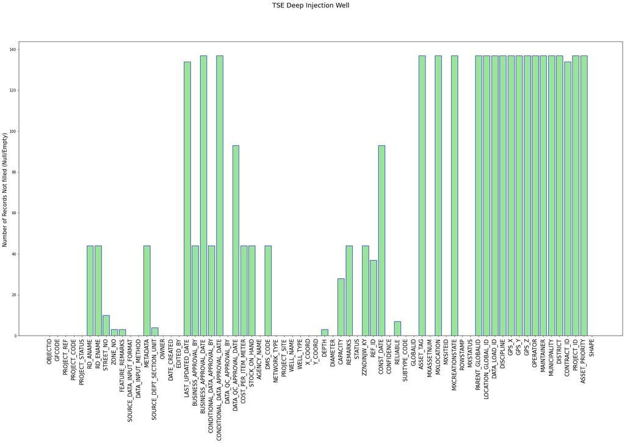

```python
x = TSE_Deep_Injection_Well.columns
y = TSE_Deep_Injection_Well.isnull().sum()
plt.figure(figsize=(30,15))
plt.bar(x, y, color= (0.2,0.8,0.2,0.5),  edgecolor='Blue')
plt.suptitle("TSE Deep Injection Well", fontsize=18)
plt.ylabel("Number of Records Not filled (Null/Empty) ", fontsize=15)
plt.xticks(rotation=90, fontsize=15)
plt.show()
```

### 16. TSE Lagoon and Tank

TSE Lagoon and Tank feature class has:

```
    •   Attribute Fields (Columns): 221
    •   Total Records (Rows): 24
```

```python
TSE_Lagoon_Tank = pd.DataFrame.spatial.from_featureclass(r"C:\Users\esd_kgathogo\AppData\Roaming\ESRI\Desktop10.7\ArcCatalog\PWAROADS.sde\SDE.DRG_TREATED_EFFLUENT_NETWORK\SDE.TENDLGON")
TSE_Lagoon_Tank.head(2)
```

|  | OBJECTID | GFCODE | FEATURE_NAME | PROJECT_CODE | PROJECT_STATUS | RD_ANAME | RD_ENAME | STREET_NO | ZONE_NO | FEATURE_REMARKS | SOURCE_DATA_INPUT_FORMAT | DATA_INPUT_METHOD | METADATA | SOURCE_DEPT_SECTION_UNIT | OWNER | DATE_CREATED | EDITED_BY | LAST_UPDATED_DATE | BUSINESS_APPROVAL_BY | BUSINESS_APPROVAL_DATE | CONDITIONAL_DATA_APPROVAL_BY | CONDITIONAL_DATA_APPROVAL_DATE | DATA_QC_APPROVAL_BY | DATA_QC_APPROVAL_DATE | COST_PER_ITEM_METER | STOCK_ON_HAND | AGENCY_NAME | DMS_CODE | TANK_NUM | … |
| --- | --- | --- | --- | --- | --- | --- | --- | --- | --- | --- | --- | --- | --- | --- | --- | --- | --- | --- | --- | --- | --- | --- | --- | --- | --- | --- | --- | --- | --- | --- |
| 0 | 12523 | TENDLGON | SGNDTANK | ERC0638 C1B | As Built | None | None | NaN | NaN | None | Excel | Manual | None | Drainage O&M | O&M Drainage | 2015-04-20 07:22:01 | Ayman | 2017-06-18 09:58:34 | None | None | ELANGO | 2015-03-22 10:15:08 | None | NaT | None | None | Ashghal | None | None | … |
| 1 | 12524 | TENDLGON | SGNDTANK | ERC0638 C1B | As Built | None | None | NaN | NaN | None | Excel | Manual | None | Drainage O&M | O&M Drainage | 2015-04-20 07:22:01 | Ayman | 2017-06-18 09:58:34 | None | None | ELANGO | 2015-03-22 10:15:08 | None | NaT | None | None | Ashghal | None | None | … |

2 rows × 221 columns

```python
TSE_Lagoon_Tank.shape
```

```
(24, 221)
```

```python
TSE_Lagoon_Tank_null = pd.DataFrame(TSE_Lagoon_Tank.isnull().sum())
```

```python
TSE_Lagoon_Tank_null
```

|  | 0 |
| --- | --- |
| OBJECTID | 0 |
| GFCODE | 0 |
| FEATURE_NAME | 19 |
| PROJECT_CODE | 2 |
| PROJECT_STATUS | 1 |
| ... | ... |
| DISTRICT | 24 |
| CONTRACT_ID | 23 |
| PROJECT_ID | 24 |
| ASSET_PRIORITY | 24 |
| SHAPE | 0 |

221 rows × 1 columns

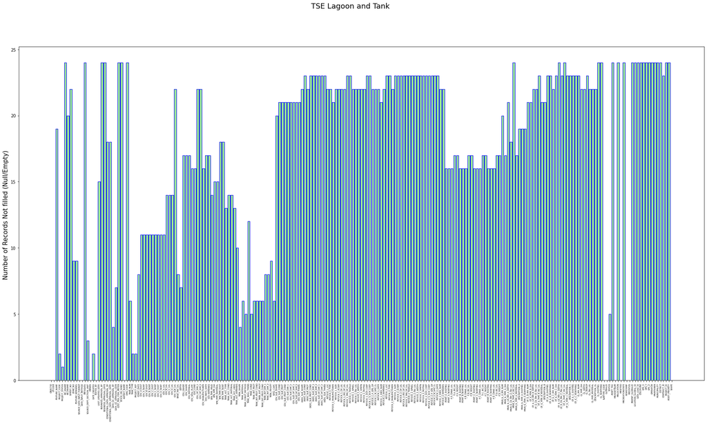

```python
x = TSE_Lagoon_Tank.columns
y = TSE_Lagoon_Tank.isnull().sum()
plt.figure(figsize=(30,15))
plt.bar(x, y, color= (0.2,0.8,0.2,0.5),  edgecolor='Blue')
plt.suptitle("TSE Lagoon and Tank", fontsize=18)
plt.ylabel("Number of Records Not filled (Null/Empty) ", fontsize=15)
plt.xticks(rotation=90, fontsize=5)
plt.show()
```

### 17. TSE Pumping Station

TSE Pumping Station feature class has:

```
    •   Attribute Fields (Columns): 78
    •   Total Records (Rows): 24
```

```python
TSE_Pumping_Station = pd.DataFrame.spatial.from_featureclass(r"C:\Users\esd_kgathogo\AppData\Roaming\ESRI\Desktop10.7\ArcCatalog\PWAROADS.sde\SDE.DRG_TREATED_EFFLUENT_NETWORK\SDE.TENDPSTN")
TSE_Pumping_Station.head(1)
```

|  | OBJECTID | GFCODE | PROJECT_CODE | PROJECT_STATUS | RD_ENAME | RD_ANAME | STREET_NO | ZONE_NO | FEATURE_REMARKS | SOURCE_DATA_INPUT_FORMAT | DATA_INPUT_METHOD | METADATA | SOURCE_DEPT_SECTION_UNIT | OWNER | DATE_CREATED | EDITED_BY | LAST_UPDATED_DATE | BUSINESS_APPROVAL_BY | BUSINESS_APPROVAL_DATE | CONDITIONAL_DATA_APPROVAL_BY | CONDITIONAL_DATA_APPROVAL_DATE | DATA_QC_APPROVAL_BY | DATA_QC_APPROVAL_DATE | COST_PER_ITEM_METER | STOCK_ON_HAND | AGENCY_NAME | DMS_CODE | PROJECT_REF | PS_NUM | … |
| --- | --- | --- | --- | --- | --- | --- | --- | --- | --- | --- | --- | --- | --- | --- | --- | --- | --- | --- | --- | --- | --- | --- | --- | --- | --- | --- | --- | --- | --- | --- |
| 0 | 13779 | TENDPSTN |  | None | Mukainis | None | 963.0 | 35.0 | ES: Changed from Abandoned to Disposed As Per ... | None | None | None | Drainage O&M | ASHGHAL | NaT | AH/PC/ES | 2020-12-21 | None | None | None | NaT | None | NaT | None | None | Ashghal | None | None | E5 | … |

```python
TSE_Pumping_Station.shape
```

```
(24, 78)
```

```python
TSE_Pumping_Station_null = pd.DataFrame(TSE_Pumping_Station.isnull().sum())
```

```python
TSE_Pumping_Station_null
```

|  | 0 |
| --- | --- |
| OBJECTID | 0 |
| GFCODE | 0 |
| PROJECT_CODE | 13 |
| PROJECT_STATUS | 7 |
| RD_ENAME | 14 |
| ... | ... |
| DISTRICT | 20 |
| CONTRACT_ID | 10 |
| PROJECT_ID | 24 |
| ASSET_PRIORITY | 19 |
| SHAPE | 0 |

78 rows × 1 columns

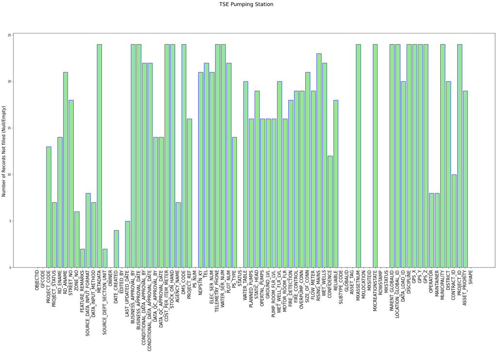

```python
x = TSE_Pumping_Station.columns
y = TSE_Pumping_Station.isnull().sum()
plt.figure(figsize=(30,15))
plt.bar(x, y, color= (0.2,0.8,0.2,0.5),  edgecolor='Blue')
plt.suptitle("TSE Pumping Station", fontsize=18)
plt.ylabel("Number of Records Not filled (Null/Empty) ", fontsize=15)
plt.xticks(rotation=90, fontsize=15)
plt.show()
```

### 18. TSE Sample Points

TSE Sample Points feature class has:

```
    •   Attribute Fields (Columns): 41
    •   Total Records (Rows): 14
```

```python
TSE_Sample_Points = pd.DataFrame.spatial.from_featureclass(r"C:\Users\esd_kgathogo\AppData\Roaming\ESRI\Desktop10.7\ArcCatalog\PWAROADS.sde\SDE.DRG_TREATED_EFFLUENT_NETWORK\SDE.TENDSPPT")
TSE_Sample_Points.head(2)
```

|  | OBJECTID | LOCATION | DIST_AREA | TSE_SPLP_NUM | TYPE | MODEL | MATERIAL | HEIGHT | NORTHING | EASTING | MAINT_AREA | CATCH_AREA | MUNICIPALITY | DISTRICT | ZONE_NO | STREET_NO | STREET_NAME | SUBTYPE_CODE | GFCODE | GLOBALID | STATUS | ASSET_TAG | MXASSETNUM | MXLOCATION | MXSITEID | MXCREATIONSTATE | ROWSTAMP | MXSTATUS | PARENT_GLOBALID | … |
| --- | --- | --- | --- | --- | --- | --- | --- | --- | --- | --- | --- | --- | --- | --- | --- | --- | --- | --- | --- | --- | --- | --- | --- | --- | --- | --- | --- | --- | --- | --- |
| 0 | 13479 | Rayyan Park | Doha West | 0 |  |  |  | 0.0 | 225630.75 | 393774.88 |  |  |  |  |  | 0 |  | 1 | TENDSPPT | {96B4ECD6-85A9-46E9-B53C-E804DCD2FF04} | Operational | None | 585099 | None | 101 | None | 56858113 | OPERATING | None | … |
| 1 | 13480 | Rumaila Park | Doha West | 0 |  |  |  | 0.0 | 230551.42 | 394082.56 |  |  |  |  |  | 0 |  | 1 | TENDSPPT | {47049D5E-8205-48D3-ACBF-0486766D7F8A} | Operational | None | 585100 | None | 101 | None | 56858114 | OPERATING | None | … |

```python
TSE_Sample_Points.shape
```

```
(14, 41)
```

```python
TSE_Sample_Points_null = pd.DataFrame(TSE_Sample_Points.isnull().sum())
```

```python
TSE_Sample_Points_null
```

|  | 0 |
| --- | --- |
| OBJECTID | 0 |
| LOCATION | 0 |
| DIST_AREA | 0 |
| TSE_SPLP_NUM | 0 |
| TYPE | 3 |
| MODEL | 3 |
| MATERIAL | 0 |
| HEIGHT | 0 |
| NORTHING | 0 |
| EASTING | 0 |
| MAINT_AREA | 4 |
| CATCH_AREA | 4 |
| MUNICIPALITY | 0 |
| DISTRICT | 0 |
| ZONE_NO | 0 |
| STREET_NO | 0 |
| STREET_NAME | 0 |
| SUBTYPE_CODE | 0 |
| GFCODE | 0 |
| GLOBALID | 0 |
| STATUS | 0 |
| ASSET_TAG | 14 |
| MXASSETNUM | 1 |
| MXLOCATION | 14 |
| MXSITEID | 1 |
| MXCREATIONSTATE | 14 |
| ROWSTAMP | 0 |
| MXSTATUS | 1 |
| PARENT_GLOBALID | 14 |
| LOCATION_GLOBAL_ID | 14 |
| DATA_LOAD_ID | 14 |
| DISCIPLINE | 14 |
| GPS_X | 14 |
| GPS_Y | 14 |
| GPS_Z | 14 |
| OPERATOR | 14 |
| MAINTAINER | 14 |
| CONTRACT_ID | 14 |
| PROJECT_ID | 14 |
| ASSET_PRIORITY | 14 |
| SHAPE | 0 |

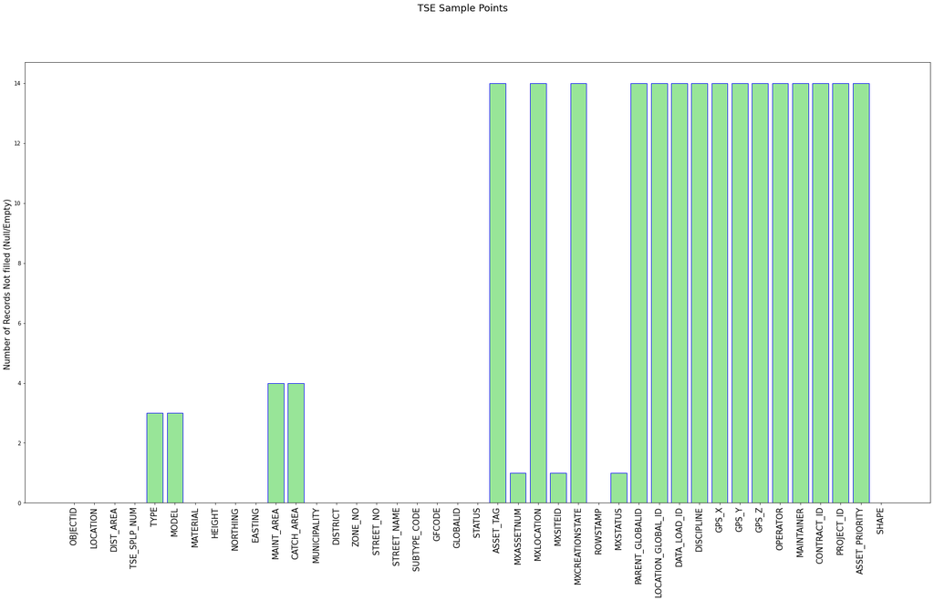

```python
x = TSE_Sample_Points.columns
y = TSE_Sample_Points.isnull().sum()
plt.figure(figsize=(30,15))
plt.bar(x, y, color= (0.2,0.8,0.2,0.5),  edgecolor='Blue')
plt.suptitle("TSE Sample Points", fontsize=18)
plt.ylabel("Number of Records Not filled (Null/Empty) ", fontsize=15)
plt.xticks(rotation=90, fontsize=15)
plt.show()
```

### 19. TSE Stub End (End Cap)

TSE Stub End (End Cap) feature class has:

[output not shown]

```python
TSE_Stub_End_Cap = pd.DataFrame.spatial.from_featureclass(r"C:\Users\esd_kgathogo\AppData\Roaming\ESRI\Desktop10.7\ArcCatalog\PWAROADS.sde\SDE.DRG_TREATED_EFFLUENT_NETWORK\SDE.TENDSTUB")
TSE_Stub_End_Cap.head(2)
```

|  | OBJECTID | GFCODE | PROJECT_CODE | PROJECT_STATUS | RD_ANAME | RD_ENAME | STREET_NO | ZONE_NO | FEATURE_REMARKS | SOURCE_DATA_INPUT_FORMAT | DATA_INPUT_METHOD | METADATA | SOURCE_DEPT_SECTION_UNIT | OWNER | DATE_CREATED | EDITED_BY | LAST_UPDATED_DATE | BUSINESS_APPROVAL_BY | BUSINESS_APPROVAL_DATE | CONDITIONAL_DATA_APPROVAL_BY | CONDITIONAL_DATA_APPROVAL_DATE | DATA_QC_APPROVAL_BY | DATA_QC_APPROVAL_DATE | COST_PER_ITEM_METER | STOCK_ON_HAND | AGENCY_NAME | DMS_CODE | NDSTUB_KY | PS_AREA | … |
| --- | --- | --- | --- | --- | --- | --- | --- | --- | --- | --- | --- | --- | --- | --- | --- | --- | --- | --- | --- | --- | --- | --- | --- | --- | --- | --- | --- | --- | --- | --- |
| 0 | 85603 | TENDSTUB | IA 14/15 C 014 ST | As Built | None | None | NaN | 69.0 | PACKAGE-2A | Excel | Manual | None | Drainage O&M | O&M Drainage | 2021-10-26 | ES | 2021-10-26 | None | NaT | None | NaT | ES | 2021-10-26 | None | None | Ashghal | None | None | None | … |
| 1 | 85615 | TENDSTUB | IA 14/15 C 014 ST | As Built | None | None | NaN | 69.0 | PACKAGE-2A | Excel | Manual | None | Drainage O&M | O&M Drainage | 2021-10-26 | ES | 2021-10-26 | None | NaT | None | NaT | ES | 2021-10-26 | None | None | Ashghal | None | None | None | … |

```python
TSE_Stub_End_Cap.shape
```

```
(3128, 63)
```

```python
TSE_Stub_End_Cap_null = pd.DataFrame(TSE_Stub_End_Cap.isnull().sum())
```

```python
TSE_Stub_End_Cap_null
```

|  | 0 |
| --- | --- |
| OBJECTID | 0 |
| GFCODE | 0 |
| PROJECT_CODE | 80 |
| PROJECT_STATUS | 50 |
| RD_ANAME | 2889 |
| ... | ... |
| DISTRICT | 3128 |
| CONTRACT_ID | 3124 |
| PROJECT_ID | 3128 |
| ASSET_PRIORITY | 3128 |
| SHAPE | 0 |

63 rows × 1 columns

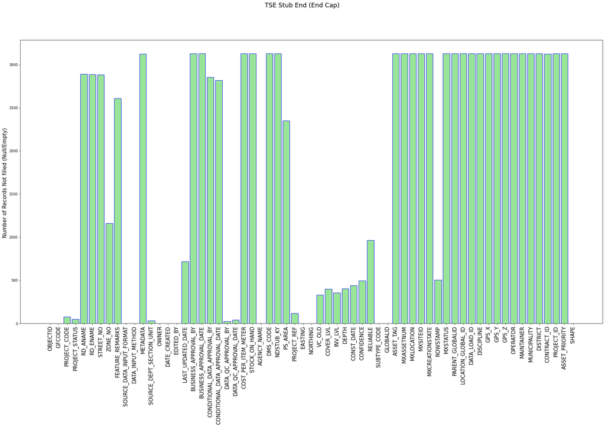

```python
x = TSE_Stub_End_Cap.columns
y = TSE_Stub_End_Cap.isnull().sum()
plt.figure(figsize=(30,15))
plt.bar(x, y, color= (0.2,0.8,0.2,0.5),  edgecolor='Blue')
plt.suptitle("TSE Stub End (End Cap)", fontsize=18)
plt.ylabel("Number of Records Not filled (Null/Empty) ", fontsize=15)
plt.xticks(rotation=90, fontsize=15)
plt.show()
```

### 20. TSE Sump

TSE Sump feature class has:

```
    •   Attribute Fields (Columns): 130
    •   Total Records (Rows): 425
```

```python
TSE_Sump = pd.DataFrame.spatial.from_featureclass(r"C:\Users\esd_kgathogo\AppData\Roaming\ESRI\Desktop10.7\ArcCatalog\PWAROADS.sde\SDE.DRG_TREATED_EFFLUENT_NETWORK\SDE.TENDSUMP")
TSE_Sump.head(2)
```

|  | OBJECTID | GFCODE | PROJECT_CODE | PROJECT_STATUS | RD_ANAME | RD_ENAME | STREET_NO | ZONE_NO | FEATURE_REMARKS | SOURCE_DATA_INPUT_FORMAT | DATA_INPUT_METHOD | METADATA | SOURCE_DEPT_SECTION_UNIT | OWNER | DATE_CREATED | EDITED_BY | LAST_UPDATED_DATE | BUSINESS_APPROVAL_BY | BUSINESS_APPROVAL_DATE | CONDITIONAL_DATA_APPROVAL_BY | CONDITIONAL_DATA_APPROVAL_DATE | DATA_QC_APPROVAL_BY | DATA_QC_APPROVAL_DATE | COST_PER_ITEM_METER | STOCK_ON_HAND | AGENCY_NAME | DMS_CODE | NDBMCH_KY | BMCH_NUM | … |
| --- | --- | --- | --- | --- | --- | --- | --- | --- | --- | --- | --- | --- | --- | --- | --- | --- | --- | --- | --- | --- | --- | --- | --- | --- | --- | --- | --- | --- | --- | --- |
| 0 | 1282 | TENDSUMP | IA 12/13 C 072 G | As Built | None | None | None | NaN | None | Excel | Automation | None | Drainage O&M | O&M Drainage | 2020-08-18 12:47:27 | BD | NaT | None | None | NULL | None | BD | 2020-08-18 12:47:29.000001 | None | None | Ashghal | None | None | None | … |
| 1 | 1601 | TENDSUMP | IA 12/13 C060 ST | As Built Yet to be Approved | None | None | None | 92.0 | None | A | Automation | None | Drainage O&M | O&M Drainage | 2020-09-13 00:00:00 | VV | 2020-09-20 11:58:25 | None | None | None | None | VV/ES | 2020-09-20 11:58:36.000000 | None | None | Ashghal | None | None | 92/531/NOH-C1/100/WOS | … |

2 rows × 130 columns

```python
TSE_Sump.shape
```

```
(425, 130)
```

```python
TSE_Sump_null = pd.DataFrame(TSE_Sump.isnull().sum())
```

```python
TSE_Sump_null
```

|  | 0 |
| --- | --- |
| OBJECTID | 0 |
| GFCODE | 0 |
| PROJECT_CODE | 61 |
| PROJECT_STATUS | 61 |
| RD_ANAME | 425 |
| ... | ... |
| PIPE_INV_LVL | 62 |
| COV_SLB_LVL | 303 |
| TAKAMUL_CATCHMENT | 43 |
| GLOBALID | 0 |
| SHAPE | 0 |

130 rows × 1 columns

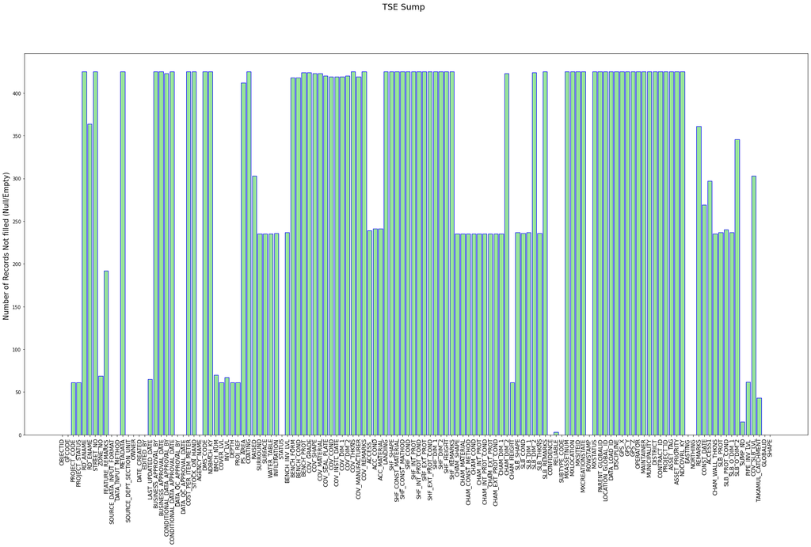

```python
x = TSE_Sump.columns
y = TSE_Sump.isnull().sum()
plt.figure(figsize=(30,15))
plt.bar(x, y, color= (0.2,0.8,0.2,0.5),  edgecolor='Blue')
plt.suptitle("TSE Sump", fontsize=18)
plt.ylabel("Number of Records Not filled (Null/Empty) ", fontsize=15)
plt.xticks(rotation=90, fontsize=12)
plt.show()
```

### 21. TSE Valve

TSE Valve feature class has:

[output not shown]

```python
TSE_Valve = pd.DataFrame.spatial.from_featureclass(r"C:\Users\esd_kgathogo\AppData\Roaming\ESRI\Desktop10.7\ArcCatalog\PWAROADS.sde\SDE.DRG_TREATED_EFFLUENT_NETWORK\SDE.TENDVALV")
TSE_Valve.head(2)
```

|  | OBJECTID | GFCODE | PROJECT_CODE | PROJECT_STATUS | RD_ANAME | RD_ENAME | STREET_NO | ZONE_NO | FEATURE_REMARKS | SOURCE_DATA_INPUT_FORMAT | DATA_INPUT_METHOD | METADATA | SOURCE_DEPT_SECTION_UNIT | OWNER | DATE_CREATED | EDITED_BY | LAST_UPDATED_DATE | BUSINESS_APPROVAL_BY | BUSINESS_APPROVAL_DATE | CONDITIONAL_DATA_APPROVAL_BY | CONDITIONAL_DATA_APPROVAL_DATE | DATA_QC_APPROVAL_BY | DATA_QC_APPROVAL_DATE | COST_PER_ITEM_METER | STOCK_ON_HAND | AGENCY_NAME | DMS_CODE | NDVALV_KY | VC_OLD | … |
| --- | --- | --- | --- | --- | --- | --- | --- | --- | --- | --- | --- | --- | --- | --- | --- | --- | --- | --- | --- | --- | --- | --- | --- | --- | --- | --- | --- | --- | --- | --- |
| 0 | 424191 | TENDVALV | IA 10/11 C 117 G | As Built | None | None | NaN | 63.0 | 63/222/P3/05/WO/2/S | Excel | Automation | None | Drainage O&M | O&M Drainage | 2021-08-12 | VV | 2021-08-30 | None | None | None | NaT | VV/ES | 2021-08-12 | None | None | Ashghal | None | NaN | 63/222/P3/05/WO | … |
| 1 | 424593 | TENDVALV | IA 12/13 C 055 ST | As Built | None | None | NaN | NaN | None | Excel | Automation | None | Drainage O&M | O&M Drainage | 2020-09-10 | VV | NaT | None | None | None | NaT | BD | 2020-09-27 | None | None | Ashghal | None | NaN | W/GRR/217/AV | … |

```python
TSE_Valve.shape
```

```
(13286, 71)
```

```python
TSE_Valve_null = pd.DataFrame(TSE_Valve.isnull().sum())
```

```python
TSE_Valve_null
```

|  | 0 |
| --- | --- |
| OBJECTID | 0 |
| GFCODE | 0 |
| PROJECT_CODE | 387 |
| PROJECT_STATUS | 2186 |
| RD_ANAME | 12026 |
| ... | ... |
| DISTRICT | 13286 |
| CONTRACT_ID | 13272 |
| PROJECT_ID | 13286 |
| ASSET_PRIORITY | 13099 |
| SHAPE | 2 |

71 rows × 1 columns

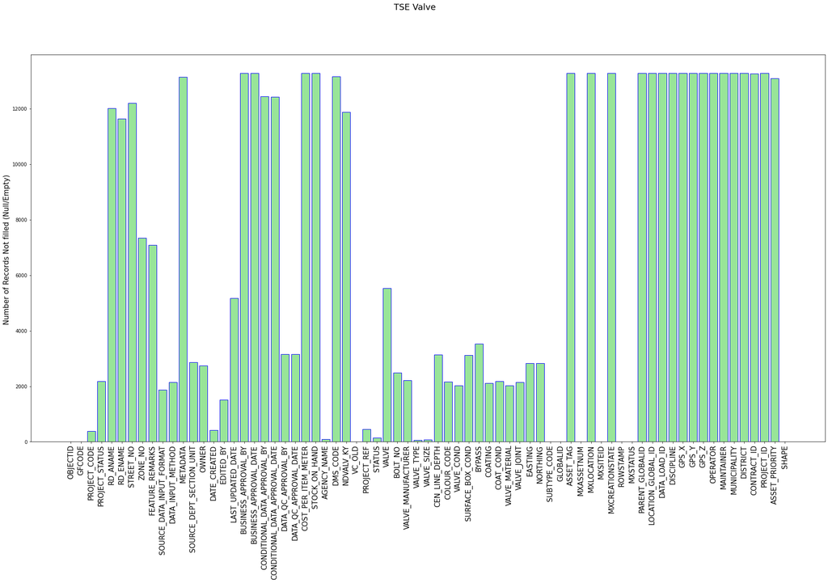

```python
x = TSE_Valve.columns
y = TSE_Valve.isnull().sum()
plt.figure(figsize=(30,15))
plt.bar(x, y, color= (0.2,0.8,0.2,0.5),  edgecolor='Blue')
plt.suptitle("TSE Valve", fontsize=18)
plt.ylabel("Number of Records Not filled (Null/Empty) ", fontsize=15)
plt.xticks(rotation=90, fontsize=15)
plt.show()
```

### 22. TSE Valve Chamber

TSE Valve Chamber feature class has:

[output not shown]

```python
TSE_Valve_Chamber = pd.DataFrame.spatial.from_featureclass(r"C:\Users\esd_kgathogo\AppData\Roaming\ESRI\Desktop10.7\ArcCatalog\PWAROADS.sde\SDE.DRG_TREATED_EFFLUENT_NETWORK\SDE.TENDVLCH")
TSE_Valve_Chamber.head(2)
```

|  | OBJECTID | GFCODE | PROJECT_CODE | PROJECT_STATUS | RD_ANAME | RD_ENAME | STREET_NO | ZONE_NO | FEATURE_REMARKS | SOURCE_DATA_INPUT_FORMAT | DATA_INPUT_METHOD | METADATA | SOURCE_DEPT_SECTION_UNIT | OWNER | DATE_CREATED | EDITED_BY | LAST_UPDATED_DATE | BUSINESS_APPROVAL_BY | BUSINESS_APPROVAL_DATE | CONDITIONAL_DATA_APPROVAL_BY | CONDITIONAL_DATA_APPROVAL_DATE | DATA_QC_APPROVAL_BY | DATA_QC_APPROVAL_DATE | COST_PER_ITEM_METER | STOCK_ON_HAND | AGENCY_NAME | DMS_CODE | NDVLCH_KY | PROJECT_REF | … |
| --- | --- | --- | --- | --- | --- | --- | --- | --- | --- | --- | --- | --- | --- | --- | --- | --- | --- | --- | --- | --- | --- | --- | --- | --- | --- | --- | --- | --- | --- | --- |
| 0 | 254477 | TENDVLCH | IA 14/15 C147 ST | As Built | None | None | NaN | NaN | None | Excel | Automation | None | Drainage O&M | O&M Drainage | 2021-05-27 | VV | None | None | None | None | NaT | VV/EA | 2021-05-31 | None | None | Ashghal | None | NaN | C2018/92 | … |
| 1 | 254324 | TENDVLCH | IA 14/15 C 014 ST | As Built | None | None | NaN | 70.0 | PACKAGE-2B | Excel | Manual | None | Drainage O&M | O&M Drainage | 2021-10-26 | ES | 2021-10-26 00:00:00 | None | None | None | NaT | ES | 2021-10-26 | None | None | Ashghal | None | NaN | C2017/113 | … |

2 rows × 106 columns

```python
TSE_Valve_Chamber.shape
```

```
(7261, 106)
```

```python
TSE_Valve_Chamber_null = pd.DataFrame(TSE_Valve_Chamber.isnull().sum())
```

```python
TSE_Valve_Chamber_null
```

|  | 0 |
| --- | --- |
| OBJECTID | 0 |
| GFCODE | 0 |
| PROJECT_CODE | 478 |
| PROJECT_STATUS | 1288 |
| RD_ANAME | 6410 |
| ... | ... |
| DISTRICT | 7114 |
| CONTRACT_ID | 7251 |
| PROJECT_ID | 7114 |
| ASSET_PRIORITY | 7261 |
| SHAPE | 0 |

106 rows × 1 columns

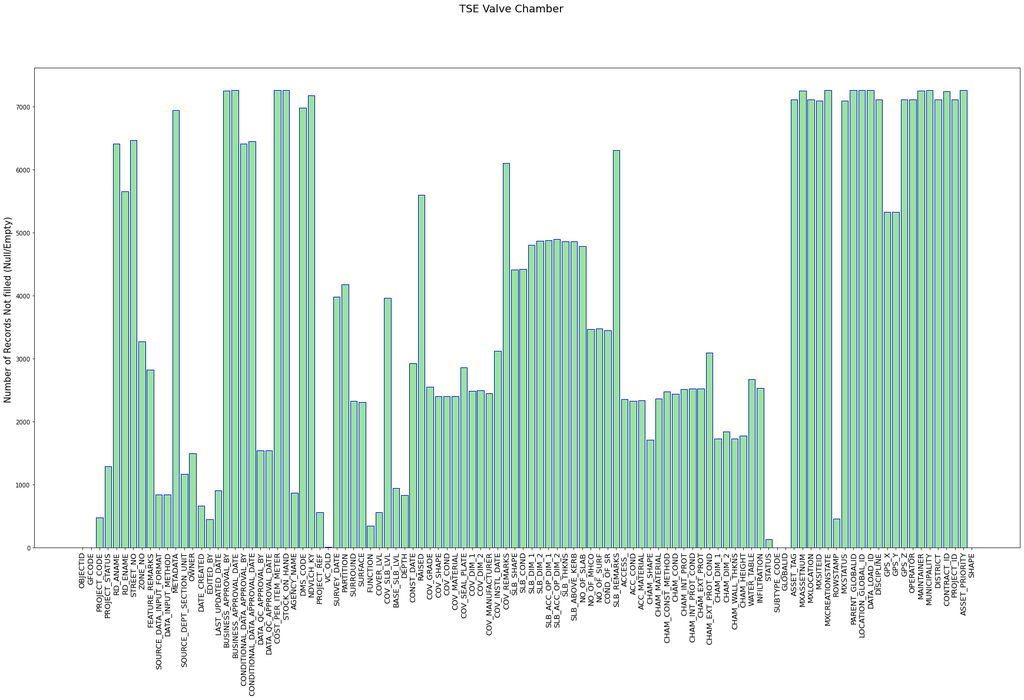

```python
x = TSE_Valve_Chamber.columns
y = TSE_Valve_Chamber.isnull().sum()
plt.figure(figsize=(30,15))
plt.bar(x, y, color= (0.2,0.8,0.2,0.5),  edgecolor='Blue')
plt.suptitle("TSE Valve Chamber", fontsize=18)
plt.ylabel("Number of Records Not filled (Null/Empty) ", fontsize=15)
plt.xticks(rotation=90, fontsize=13)
plt.show()
```

### 23. TSE Water Tower

TSE Water Tower feature class has:

```
    •   Attribute Fields (Columns): 80
    •   Total Records (Rows): 8
```

```python
TSE_Water_Tower = pd.DataFrame.spatial.from_featureclass(r"C:\Users\esd_kgathogo\AppData\Roaming\ESRI\Desktop10.7\ArcCatalog\PWAROADS.sde\SDE.DRG_TREATED_EFFLUENT_NETWORK\SDE.TENDWTTR")
TSE_Water_Tower.head(2)
```

|  | OBJECTID | GFCODE | PROJECT_CODE | PROJECT_STATUS | RD_ANAME | RD_ENAME | STREET_NO | ZONE_NO | FEATURE_REMARKS | SOURCE_DATA_INPUT_FORMAT | DATA_INPUT_METHOD | METADATA | SOURCE_DEPT_SECTION_UNIT | OWNER | DATE_CREATED | EDITED_BY | LAST_UPDATED_DATE | BUSINESS_APPROVAL_BY | BUSINESS_APPROVAL_DATE | CONDITIONAL_DATA_APPROVAL_BY | CONDITIONAL_DATA_APPROVAL_DATE | DATA_QC_APPROVAL_BY | DATA_QC_APPROVAL_DATE | COST_PER_ITEM_METER | STOCK_ON_HAND | AGENCY_NAME | DMS_CODE | NDWTTR_KY | TOWER_NUM | … |
| --- | --- | --- | --- | --- | --- | --- | --- | --- | --- | --- | --- | --- | --- | --- | --- | --- | --- | --- | --- | --- | --- | --- | --- | --- | --- | --- | --- | --- | --- | --- |
| 0 | 9945 | TENDWTTR |  | None | None | None | None | None | None | None | None | None | None | None | 1996-01-01 | None | NaT | None | None | None | None | None | None | None | None | Ashghal | None | 0 | T4 | … |
| 1 | 9946 | TENDWTTR |  | None | None | None | None | None | None | None | None | None | None | None | 1996-01-01 | None | NaT | None | None | None | None | None | None | None | None | Ashghal | None | 0 | T8 | … |

```python
TSE_Water_Tower.shape
```

```
(8, 80)
```

```python
TSE_Water_Tower_null = pd.DataFrame(TSE_Water_Tower.isnull().sum())
```

```python
TSE_Water_Tower_null
```

|  | 0 |
| --- | --- |
| OBJECTID | 0 |
| GFCODE | 0 |
| PROJECT_CODE | 0 |
| PROJECT_STATUS | 8 |
| RD_ANAME | 8 |
| ... | ... |
| DISTRICT | 8 |
| CONTRACT_ID | 8 |
| PROJECT_ID | 8 |
| ASSET_PRIORITY | 8 |
| SHAPE | 0 |

80 rows × 1 columns

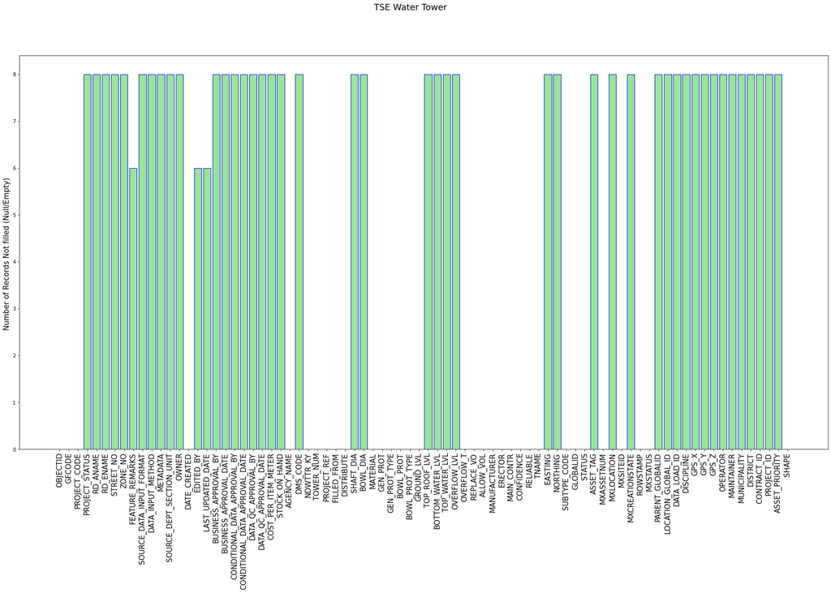

```python
x = TSE_Water_Tower.columns
y = TSE_Water_Tower.isnull().sum()
plt.figure(figsize=(30,15))
plt.bar(x, y, color= (0.2,0.8,0.2,0.5),  edgecolor='Blue')
plt.suptitle("TSE Water Tower", fontsize=18)
plt.ylabel("Number of Records Not filled (Null/Empty) ", fontsize=15)
plt.xticks(rotation=90, fontsize=15)
plt.show()
```